# dad: an R Package for Visualisation, Classification and Discrimination of Multivariate Groups Modelled by their Densities

Multidimensional scaling (MDS), hierarchical cluster analysis (HCA), and discriminant analysis (DA) are classical techniques which deal with data made of $n$ individuals and $p$ variables. When the individuals are divided into $T$ groups, the R package *dad* associates with each group a multivariate probability density function and then carries out these techniques on the densities, which are estimated by the data under consideration. These techniques are based on distance measures between densities: chi-square, Hellinger, Jeffreys, Jensen-Shannon, and $L^p$ for discrete densities, Hellinger , Jeffreys, $L^2$, and 2-Wasserstein for Gaussian densities, and $L^2$ for numeric non-Gaussian densities estimated by the Gaussian kernel method. Practical methods help the user to give meaning to the outputs in the context of MDS and HCA and to look for an optimal prediction in the context of DA based on the one-leave-out misclassification ratio. Some functions for data management or basic statistics calculations on groups are annexed.

Rachid Boumaza (IRHS-UMR1345, Université d’Angers, INRAE, Institut Agro, SFR 4207 QuaSaV) , Pierre Santagostini (IRHS-UMR1345, Université d’Angers, INRAE, Institut Agro, SFR 4207 QuaSaV) , Smail Yousfi (Université Mouloud Mammeri) , Sabine Demotes-Mainard (IRHS-UMR1345, Université d’Angers, INRAE, Institut Agro, SFR 4207 QuaSaV)  
2021-08-17

## 1 Introduction

Techniques such as multidimensional scaling, hierarchical cluster analysis, and discriminant analysis are often used for multivariate data analysis to visualize, organize observations into groups, and model class structure, respectively.

These techniques deal with data of the “individuals $\times$ variables” type (Mardia et al. 1979; Krzanowski 1988), commonly stored in objects of class `data frame`. These techniques are available in the R packages [*stats*](https://CRAN.R-project.org/package=stats), [*MASS*](https://CRAN.R-project.org/package=MASS) (Venables and Ripley 2002), [*ade4*](https://CRAN.R-project.org/package=ade4) (Dray et al. 2007), [*FactoMineR*](https://CRAN.R-project.org/package=FactoMineR) (Lê et al. 2008), [*cluster*](https://CRAN.R-project.org/package=cluster) (Maechler et al. 2019).

In the case where the individuals are organized into occasions or groups, the analyst could be interested in taking into account this data organization by associating with each occasion a mathematical object and performing multivariate techniques on these objects. In the [*dad*](https://CRAN.R-project.org/package=dad) package (Boumaza et al. 2021), devoted to such data, the objects are probability density functions. These densities are either all continuous (numeric data with Lebesgue measure as reference measure) or all discrete (categorical data with counting measure as reference measure) and are subjected to the following analyses:

- Multidimensional scaling (MDS) of probability density functions aims to visualize a set of densities (or occasions) so that the distances between the densities are preserved as well as possible;
- Hierarchical cluster analysis (HCA) of probability density functions is used to divide a set of densities (or occasions) into clusters so that the densities of the same cluster are as similar as possible and are dissimilar from those of the other clusters;
- Discriminant analysis (DA) of probability density functions deals with the same kind of data, knowing a partition of the densities (or occasions) into classes. Its first objective is to learn how the a priori classes can be explained by the distances between these densities. Then, if the training step is judged satisfactory according to a criterion named misclassification ratio, its second objective is to classify a new density whose class is unknown (Boumaza 2004).

These three multivariate techniques constitute the core of this work. Theoretically, the *dad* package handles probability density functions and considers multi-group data as samples allowing their estimation. The densities could be considered as functional data processed by packages like [*fda*](https://CRAN.R-project.org/package=fda) (Ramsay et al. 2020), [*fda.usc*](https://CRAN.R-project.org/package=fda.usc) (Febrero-Bande and Fuente 2012), or [*fdadensity*](https://CRAN.R-project.org/package=fdadensity) (Petersen et al. 2019), or as compositional data processed by packages like [*compositions*](https://CRAN.R-project.org/package=compositions) (Tsagris and Athineou 2020), [*Compositional*](https://CRAN.R-project.org/package=Compositional) (van den Boogaart et al. 2020), or [*robCompositions*](https://CRAN.R-project.org/package=robCompositions) (Filzmoser et al. 2018). The differences or similarities with these approaches are the subjects of part of the discussion of the manuscript (*Discussion and concluding remarks* Section).

These three multivariate techniques are essentially based on distance indices between probability density functions. Literature abounds with such indices: as an example, the encyclopedia of distances of Deza and Deza (2013 235–245) lists some forty. The *dad* package proposes to calculate ten of them among the most common by considering the case of discrete densities and that of continuous densities. The results returned by the three previous multivariate techniques depend on the distance index used. This is illustrated by simple examples in the context of HCA (Appendix A) or DA (Appendix B), and criteria of distance choice are proposed in the *Practical advice* Section.

Thus, for each distance index, the *dad* package implements:

- its calculation for two densities whose type and parameters are known,
- its estimation for two densities for which there are two samples which allow the estimation of their parameters,
- the generalization of each previous calculation for $T$ ($T > 2$) densities taken two by two, the result of which is a symmetric matrix.

In order to avoid unnecessary redundancies in the entry of data characterizing the groups as these characteristics are the same for all the individuals of the same group, we considered it useful to organize the data in a list of data frames (object of class `folderh`). Also, in order to calculate some statistics (means, covariance matrices...) per group or distances between each pair of groups, we considered it useful to store the individuals of each group in one data frame and these data frames in a list (object of class `folder`). Appendix C details the rationale for introducing these object classes. The functions of the package *dad* implementing the three main techniques (MDS, HCA, DA) apply to such objects. The functions of data management or elementary calculation (means, variance or correlation matrices, moments) applying to these objects could have been made invisible in the package without affecting the presentation of the main techniques. However, to facilitate the work of the analyst interested in processing multi-group data or in experimenting with other multivariate techniques on such data, we have kept them visible. Some of them are presented in Appendix C and Appendix D.

So, the presentation of the *dad* package will begin with a description of the data considered in the previous techniques (*Multi-group data: examples and organization* Section). We will then present functions for the calculation of the distance or divergence measures between discrete densities and between Gaussian densities. The special case of non-Gaussian densities estimated with the Gaussian kernel method is also considered (*Distance / divergence between densities* Section). Then, we will present the functions implementing the three techniques introduced above for the processing of multi-group data: multidimensional scaling (*MDS of densities* Section), hierarchical cluster analysis (*HCA of densities* Section), and discriminant analysis (*DA of densities* Section). Finally, we will give some practical advice (*Practical advice* Section) and briefly highlight some similarities with functions of other R packages (*Discussion and concluding remarks* Section). A summary and appendices complete this presentation.

## 2 Multi-group data: examples and organization

Table 1: For each occasion $t = 1,\ldots,T$, the same $p$ variables are observed for $n_t$ individuals. The data frame (a) consists of ($p+1$) columns, the last one is a factor designating the occasion. The data folder (b) consists of $T$ data frames each one having the same $p$ column names.

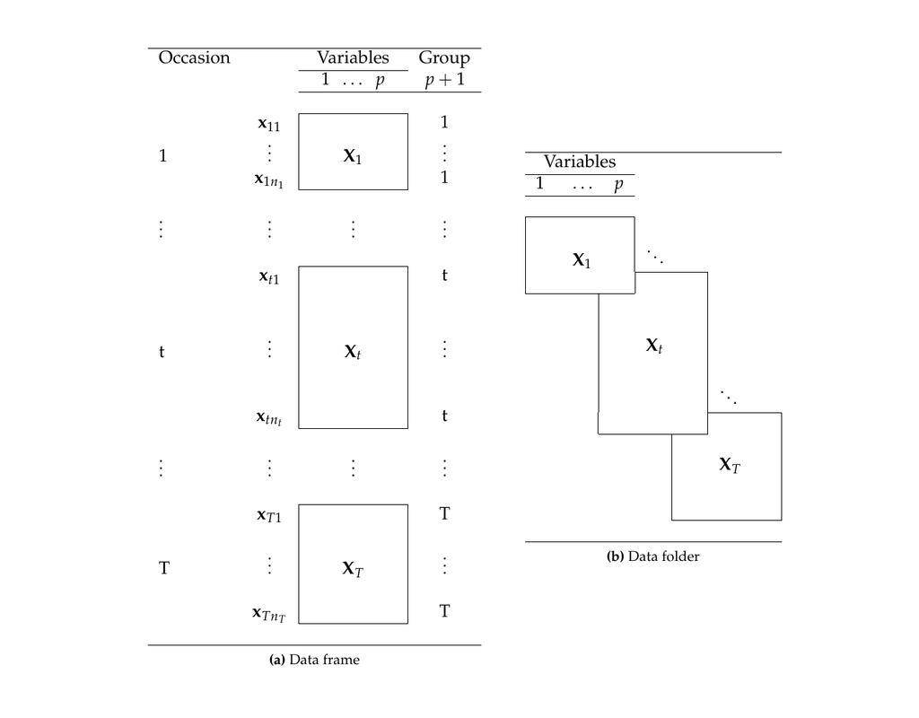

Table 2: Each occasion $t$ ($t=1,\ldots,T$) matches a table with $n_t$ rows and $p$ columns (see Table 1). The variable $G$ defined on the occasions takes values $\{1,\ldots,K\}$. For each $k=1,\ldots,K$, the value $k$ is taken $T_k$ times. The $G$ values of the occasions $T+1,\,\ldots$ are not available and have to be predicted.

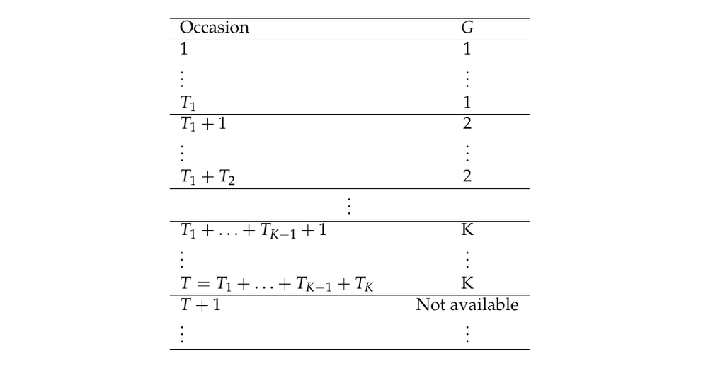

For MDS and HCA, the data $\mathbf{X}$ (Table 1a) of interest have three kinds of objects: occasions $\times$ individuals $\times$ variables. The occasions define a partition of the individuals on which the variables are measured. If $T$ denotes the number of occasions, for each $t$ in $\left\{1,\ldots,T\right\}$, the rows of the table $\mathbf{X}_t$ correspond to $n_t$ observations $\mathbf{x}_{t1}\,,\ldots,\,\mathbf{x}_{tn_t}$ of $X_t$ a random vector with $p$ components.

For DA, the data of interest are similar to the previous ones with the difference that we have two categories of occasions. The first category consisting of $T$ occasions is partitioned into $K$ subsets deriving from a factor $G$ defined on occasions (Table 2). The second category consists of occasions, numbered $T+1,\ \ldots$ for which we have data of type $\mathbf{X}$ but not the value of $G$.

### 2.1 Datasets

The data of the following examples are available in the *dad* package as lists of data frames or arrays, and are loaded by means of the usual `data` function.

1. Archaeological data: the data are stored in `castles.dated`, a list of two data frames whose description is detailed in the subsection *Introductory example* of Appendix C. The data frame `castles.dated$stones` in which for each of $T=68$ Alsatian castles (occasions), $p=4$ numerical characteristics are measured on a batch of stones (individuals) used to build the castle. The objective is to:
   - visualize the castles by points in a space of reduced dimension so that the castles having stones of similar dimensions are close to each other and those having stones of very different dimensions are distant;
   - highlight which characteristics of the stones are at the origin of these small or large distances.

   The $68$ castles are dated from the period 1140-1650, which is divided into six intervals, numbered 1 to 6, separated by the following cutoff points: 1175, 1210, 1245, 1280, 1350. The building periods are available in the data frame `castles.dated$periods`. The first objective is to analyse the relations between these periods and the previous visualization of the castles. The second objective is to predict the building period of $67$ non-dated castles the data of which are in the data frame `castles.nondated$stones`.  
   This archaeological example (Rudrauf and Boumaza 2001) was at the origin of the multi-group techniques presented in this work. It illustrates well the MDS and DA techniques even if, as we will see when processing the data, from the archeology point of view, the results are not very satisfactory and have only an indicative value.
2. Agronomic data: the data are stored in the `folderh` object `varietyleaves` consisting of two data frames `variety` and `leaves`, and a key `rose` that is the column name common to the two data frames which connects them. The first data frame `varietyleaves$leaves` is made up of $581$ rows (leaves of $T = 31$ rosebushes) and 5 columns corresponding to the number of the rosebush to which the leaf belongs and $p = 4$ numerical characteristics: number of its leaflets, length of its rachis, then the length, and width of its main leaflet. The second data frame `varietyleaves$variety` is made up of $T$ rows and two columns: the number of the rosebush and its variety. There are $K = 6$ varieties (Table 3). This example will illustrate the DA technique. The objective of which is to predict the variety of one plant from measures of several leaves of the plant.

   Table 3: Numbers of plants and leaves per variety and number of leaves per plant.

   | Variety | Number | Number | Number of leaves |
   | --- | --- | --- | --- |
   |  | of plants | of leaves | per plant |
   | Canary | 6 | 65 | $=\ \ 8+14+11+16+\ 8+\ 8$ |
   | Electron | 3 | 42 | $=\ \ 9+\ 8+25$ |
   | Lili Marleen | 6 | 65 | $=\ 15+10+\ 5+\ 7+15+13$ |
   | Pussta | 6 | 200 | $=\ 35+47+29+20+37+32$ |
   | Starina | 5 | 105 | $=\ 18+17+19+33+18$ |
   | White Meillandina | 5 | 104 | $=\ 23+19+16+22+24$ |

### 2.2 Data management

The previously collected data can be organized into:

- A single data frame (Table 1a), by vertically concatenating the $T$ tables $\mathbf{X}_t$, with $p$ columns and appending a factor column designating the occasion, or
- A list of $T$ data frames (Table 1b), each having $p$ columns, as an object from an `S3` class named `folder` (see Appendix C).

To carry out discriminant analysis, the training step requires an a priori division of the occasions into clusters, that is, a factor $G$ with $K$ levels defined from the occasion set (Table 2). The predicting step is to assign a level for each occasion whose value of the factor $G$ is not available. The data, therefore, consist of two data frames linked by a hierarchical relationship “1 to N”. Each row of the data frame in Table 2 is, thus, matched to several rows of the data frame in Table 1a. The list of these two data frames is an object of `S3` class `folderh` (hierarchical folder) built by the function `folderh` (see Appendix C).

Notice that in the presentation of the data tables, we arranged them so that the individuals (rows of Table 1a) of the same occasion are neighbors and so that the occasions (rows of Table 2) of the same class are neighbors. However, in the *dad* package, such a layout is obviously not necessary. Only the factors $Group$ (Table 1a) and $G$ (Table 2) must be given.

## 3 Distance/divergence between densities

In the first subsection, we present the indices which operate on discrete densities. In the second subsection, we consider the indices which operate on Gaussian densities and have an analytical expression depending on the parameters of the densities: means, variances, and covariances. Therefore, these indices can easily be estimated from the parameter estimates. In the third subsection, we present an index based on the estimation of densities on $\mathbb{R}^p$ by the Gaussian kernel method. This index offers the advantage of being easily calculable even for non-Gaussian continuous densities.

The main techniques of the *dad* package depend on the distance index used (Appendix A and B). A brief practical guidance on the choice of distance index is provided in *Practical advice* Section.

### 3.1 Calculation of distances/divergences between discrete densities

Table 4: Distance indices between two discrete densities $p_1$ and $p_2$ on the same finite support the states of which are denoted $x$ in the formulas. The sums of the formulas are taken over all the states of the support (Deza and Deza 2013). The corresponding *dad* functions are: `ddchisqsympar`, `ddhellingerpar`, `ddjeffreyspar`, `ddjensenpar`, and `ddlppar`.

| Name | Expression |
| --- | --- |
| Symmetric chi-square | $\sum\limits_{x}{(p_1(x)-p_2(x))^2 / (p_1(x) + p_2(x))}$ |
| Hellinger | $\left( 2 \sum\limits_{x}{(\sqrt{p_1(x)}-\sqrt{p_2(x)}\;)^2} \right)^{\frac{1}{2}}$ |
| Jeffreys | $\sum\limits_{x}{ (p_1(x)-p_2(x)) \ \ln (p_1(x)/p_2(x)) }$ |
| Jensen-Shannon | $\sum\limits_{x} \left( \ p_1(x) \ \ln (2 p_1(x)/ (p_1(x)+p_2(x))) \right.$ |
|  | $\left. + \ p_2(x) \ \ln (2 p_2(x)/ (p_1(x)+p_2(x)))\ \right)$ |
| Lp | $\left( \sum\limits_{x}{\|p_1(x)-p_2(x)\|^p} \right)^{\frac{1}{p}}$ |

Table 4 lists the expressions of distance indices of two discrete densities and the *dad* functions associated with them. The set of the states of these densities can be either the set of the levels of one categorical variable or the Cartesian product of the $q$ sets of the levels of $q$ categorical variables as in the following example with $q=2$.

```r
> x1 <- data.frame(x = factor(c("A", "A", "A", "B", "B", "B")),
+                  y = factor(c("a", "a", "a", "b", "b", "b")))
> x2 <- data.frame(x = factor(c("A", "A", "A", "B", "B")),
+                  y = factor(c("a", "a", "b", "a", "b")))
> p1 <- table(x1)/nrow(x1)
> p1
   y
x     a   b
  A 0.5 0.0
  B 0.0 0.5
> p2 <- table(x2)/nrow(x2)
> p2
   y
x     a   b
  A 0.4 0.2
  B 0.2 0.2
```

The $L1$ distance and Jeffreys divergence between the densities $p1$ and $p2$ are computed as follows.

```r
> ddlppar(p1, p2)
[1] 0.8
> ddjeffreyspar(p1, p2)
[1] Inf
```

The Jensen-Shannon index is equal to the entropy or average quantity of information of the distribution $(p_1 + p_2) / 2$, from which we subtract the sum of the entropies of $p_1$ and $p_2$. The other indices are based on the sum of the differences, possibly weighted, between $p_1$ and $p_2$ in each state $x$, unlike the Jensen-Shannon index, which is somewhat more global. These indices are compared in the subsection *Simulated discrete data* of Appendix B.

### 3.2 Calculation of distances/divergences between Gaussian densities

Table 5 lists the parametric expressions of distance indices of multivariate densities and the *dad* functions associated with them. For the univariate case, the expressions are easily deduced.

Table 5: Distance indices between the multivariate Gaussian densities $f \equiv N(\mu,\Sigma)$ and $g \equiv N(m,V)$. (a) The corresponding *dad* function is `hellingerpar`. It is the $L^2$ distance between the square roots of the densities $f$ and $g$. (b) The Jeffreys divergence is the symmetrized Kullback-Leibler divergence. Its corresponding function is `jeffreyspar`. (c) The corresponding function of the $L^2$ distance is `distl2dpar`. (d) L2N, named also normalized $L^2$ distance, stands for the $L^2$ distance between $f/\|f\|_{L^2}$ and $g/\|g\|_{L^2}$ and its value is almost similar to the Hellinger distance. Its corresponding function is `distl2dnormpar`. (e) $I_p$ stands for the identity matrix of order $p$. The corresponding function is `wassersteinpar`.

| Name | Expression |
| --- | --- |
| Hellinger $^{\textrm{(a)}}$ | $\left(2 - 2^{\frac{p}{2}+1} \det(\Sigma V)^{\frac{1}{4}} \det(\Sigma + V)^{-\frac{1}{2}} \exp(-\frac{1}{4} \\|\mu-m\\|^2_{(\Sigma+V)^{-1}} )\right)^{\frac{1}{2}}$ |
| Jeffreys$^{\textrm{(b)}}$ | $2^{-1}\, \\|\mu-m\\|^2_{\Sigma^{-1}+V^{-1}} + 2^{-1}\, \textrm{tr}((\Sigma-V)(V^{-1}-\Sigma^{-1}))$ |
| L2 $^{\textrm{(c)}}$ | $\left( (2\pi)^{-\frac{p}{2}} \det(2\Sigma)^{-\frac{1}{2}} + (2\pi)^{-\frac{p}{2}} \det(2V)^{-\frac{1}{2}} \right.$ |
|  | $\left. - 2\,(2\pi)^{-\frac{p}{2}} \det(\Sigma + V)^{-\frac{1}{2}} \exp(-\frac{1}{2} \\|\mu-m\\|^2_{(\Sigma + V)^{-1}} ) \right)^{\frac{1}{2}}$ |
| L2N $^{\textrm{(d)}}$ | $\left(2 - 2^{\frac{p}{2}+1} \det(\Sigma V)^{\frac{1}{4}} \det(\Sigma + V)^{-\frac{1}{2}} \exp(-\frac{1}{2} \\|\mu-m\\|^2_{(\Sigma+V)^{-1}} )\right)^{\frac{1}{2}}$ |
| 2-Wasserstein $^{\textrm{(e)}}$ | $\left(\\|\mu-m\\|^2_{I_p} + \textrm{tr}(\Sigma + V - 2(V^{\frac{1}{2}} \Sigma V^{\frac{1}{2}})^{\frac{1}{2}})\right)^{\frac{1}{2}}$ |

For example, the Jeffreys divergence is respectively carried out with the `jeffreyspar` or `jeffreys` functions depending on whether the calculations are respectively based on parameters or samples.

```r
> m1 <- c(1,1)
> v1 <- matrix(c(4,1,1,9),ncol = 2)
> m2 <- c(0,1)
> v2 <- matrix(c(1,0,0,1),ncol = 2)
> jeffreyspar(m1,v1,m2,v2)
```

```r
[1] 5.314286
```

```r
> library(MASS)
> set.seed(100)
> x1 <- mvrnorm(40, m1, v1)
> x2 <- mvrnorm(30, m2, v2)
> jeffreys(x1, x2)
```

```r
[1] 6.780999
```

All these indices are based on a combination of the difference between the means $\mu$ and $m$ and the dissimilarity between the covariance matrices $\Sigma$ and $V$. In the case of equal means, the distance index between Gaussian densities reduces to a dissimilarity between covariance matrices. If the covariance matrices are equal, all these indices reduce to an index of the distance between these means, this index being dependent on the common variance matrix, with the exception of the Wasserstein index, which uses the identity matrix. These indices are also compared in the subsection *Simulated Gaussian data* of Appendix B.

### 3.3 Calculation of $L^2$ distances between continuous non-Gaussian densities estimated by the kernel method

Except for the $L^2$ distances, the extension of the other distance indices of Table 5 to any estimated densities still requires a lot of work. Indeed, we experimented with calculating distance indices using numerical integration methods but computation times were so long in the multidimensional case that we did not implement them in the *dad* package. The solution we recommend is to estimate the densities by the Gaussian kernel method and use the $L^2$ distances.

- **Density estimation with the Gaussian kernel method.** The probability densities $f_t$ are estimated by the Gaussian kernel method:
  $$\label{densiteng}
  \hat{f}_t(\mathbf{z})=\frac{1}{n_t|\mathbf{h}_t|^{1/2}}\frac{1}{(2\pi)^{p/2}}\sum_{i=1}^{n_t}\exp(-\frac{1}{2}(\mathbf{z}-\mathbf{x}_{ti})^\top
  \mathbf{h}_t^{-1}(\mathbf{z}-\mathbf{x}_{ti}))\text{,} \tag{1}$$
  where $\mathbf{h}_t$ is the non-singular bandwidth matrix and $|\mathbf{h}_t|$ its determinant. This matrix may be provided by the user, or calculated directly according to the AMISE criterion, with reference to the normal distribution (Wand and Jones 1995), that is:
  $$\label{bandwidth}
  \mathbf{h}_t=h_t\widehat{\mathbf{V}}_t^{1/2}\text{,} \tag{2}$$
  with:
  $$\label{windowh_normal_reference}
  h_t=\Big(\frac{4}{n_t(p+2)}\Big)^{\frac{1}{p+4}}. \tag{3}$$
- **Calculation of $L^2$ distances between estimated non-Gaussian densities.** The calculation of the inner product is carried out with the `l2d` function using a sample per density: `x1` and `x2`; the result derives from the estimation ((1)) of the densities, the bilinearity of the inner product, and a formula of integral calculus (Wand and Jones 1995 101). Then, the $L^2$-distance is directly deduced. This calculation is carried out with the `distl2d` function.

  ``` r
  [1] 0.2562896
  ````

The normalized $L^2$ distance between densities is also possible. Although it has the disadvantage of being time-consuming, it has some similarities to Hellinger’s distance, and in the Gaussian case, the two distances have almost the same expression (Table 5).

## 4 MDS of densities

Since the function of *dad* package implementing multidimensional scaling of probability density functions is a direct application of the function `cmdscale` of R, it is briefly recalled in the case of continuous densities. The mathematical aspects of this method have been dealt with in several works (Delicado (2011) as MDS; Boumaza (1998), Kneip and Utikal (2001), and Yousfi et al. (2015) as functional PCA). In this section, we will privilege the presentation in MDS form, which offers greater flexibility in the choice of the distance between densities, while taking inspiration from the method of interpretation of the results of PCA developed in Boumaza et al. (2015) in order to interpret the scores resulting from MDS.

### 4.1 Brief presentation of the method

Given $T$ densities and $(\delta_{ts})_{1\leq t,s\leq T}$ the distances/divergences between each pair of them, the MDS technique looks for a representation of the densities by $T$ points in a low dimensional space such that the distances between these points are as similar as possible to the $(\delta_{ts})$ (Cox and Cox 2001). In R, this multidimensional positioning technique is performed by the `cmdscale` function, whose main argument is the symmetric matrix of distances and the main output is the matrix of coordinates.

If the densities are assumed to be Gaussian, we can use the Hellinger distance, the Jeffreys divergence, the 2-Wasserstein distance, or the $L^2$ distance (Table 5). If they are not expected to be Gaussian, they are estimated using the Gaussian kernel method, and the only available distance for the moment is the $L^2$-distance (*Calculation of $L^2$ distances between continuous non-Gaussian densities estimated by the kernel method* Section).

The *dad* package includes functions for all the calculations required to implement such a method and to interpret its outputs:

- The `fmdsd` function which performs multidimensional scaling and generates scores;
- The `plot` function which generates graphics representing the densities on the factorial axes;
- The `interpret` function which returns other aids to interpretation based on the moments of the variables.

### 4.3 Interpretation of `fmdsd` outputs

The `fmdsd` function returns an object of `S3` class `fmdsd`, consisting of a list of 11 elements, including the scores, also called principal coordinates, and the moments of the variables per occasion. The outputs are displayed with the `print` function, and graphical representations on the principal planes are generated with the `plot` function.

The interpretation of outputs is based on the relationships between the principal scores and the moments of the densities, in particular their means, variances, covariances, and correlations. These relationships are quantified by correlation coefficients and are represented graphically by plotting the scores against the moments. These interpretation tools are provided by the `interpret` function, which has two optional arguments: `nscores` indicating the indices of the column scores to be interpreted and `moment` whose default value is `"mean"`.

### 4.4 Example

The following example is treated in detail in Boumaza et al. (2015), using PCA of densities. The data consist of $T = 10$ rose bushes assessed three times, by a jury of 14 assessors, for $p = 3$ attributes: top-sided shape ($Sha$), foliage thickness ($Den$), and plant symmetry ($Sym$). Here, we present the results obtained with the MDS technique. This presentation is limited to the major steps in the calculation and the visualization of the results generated by the `fmdsd`, `print`, `plot`, and `interpret` functions.

```r
> data("roses")
> rosesf <- as.folder(roses[,c("Sha", "Den", "Sym", "rose")], groups = "rose")
> resultmds <- fmdsd(rosesf, gaussiand = FALSE, distance = "l2")
```

The function `fmdsd` displays the barplot of the inertia explained by the first nine principal coordinates (Figure 1).

```r
> names(resultmds)
```

```r
 [1] "call"         "group"        "variables"    "d"            "inertia"      "scores"
 [7] "means"        "variances"    "correlations" "skewness"     "kurtosis"
```

By default, the `print` function applied to `resultmds` only displays the names of the variables, the inertia, and the principal coordinates.

```r
> print(resultmds)
```

```r
group variable:  rose
variables:  Sha Den Sym
---------------------------------------------------------------
inertia
  eigenvalue inertia
1    0.02977    25.3
2    0.02261    19.2
3    0.02028    17.2
4    0.01439    12.2
5    0.00980     8.3
6    0.00930     7.9
7    0.00566     4.8
8    0.00344     2.9
9    0.00262     2.2
---------------------------------------------------------------
coordinates
  rose         PC.1         PC.2        PC.3
A    A  0.055191062  0.022167510  0.02655143
B    B -0.004963751 -0.023764758  0.07033084
C    C  0.019611171 -0.122241048 -0.06566866
D    D -0.091777346  0.041132410 -0.04995275
E    E -0.013763431  0.019828288 -0.01341398
F    F  0.016470141 -0.024307858  0.07144865
G    G -0.088949736  0.005722199  0.01223686
H    H -0.025102407 -0.006365474  0.01382440
I    I  0.068203593  0.043999532 -0.02735366
J    J  0.065080705  0.043829197 -0.03800313
```

```r
> plot(resultmds)
```

The output is shown in Figure 2.

```r
> interpret(resultmds)
```

```r
Pearson correlations between scores and moments
          PC.1  PC.2  PC.3
mean.Sha -0.65  0.29  0.69
mean.Den  0.83 -0.42  0.08
mean.Sym -0.01  0.94 -0.04
Spearman correlations between scores and moments
          PC.1  PC.2  PC.3
mean.Sha -0.65 -0.26  0.65
mean.Den  0.78 -0.30  0.02
mean.Sym  0.16  0.92 -0.35
```

The returned plots of the `interpret` function are not shown. From the correlations between the principal coordinates (PC) and the means of the variables, we deduce that:

- The higher PC1, the higher "Den", and the lower "Sha" tends to be;
- The higher PC2, the higher "Sym";
- The higher PC3, the higher "Sha" tends to be.

[figure not shown]

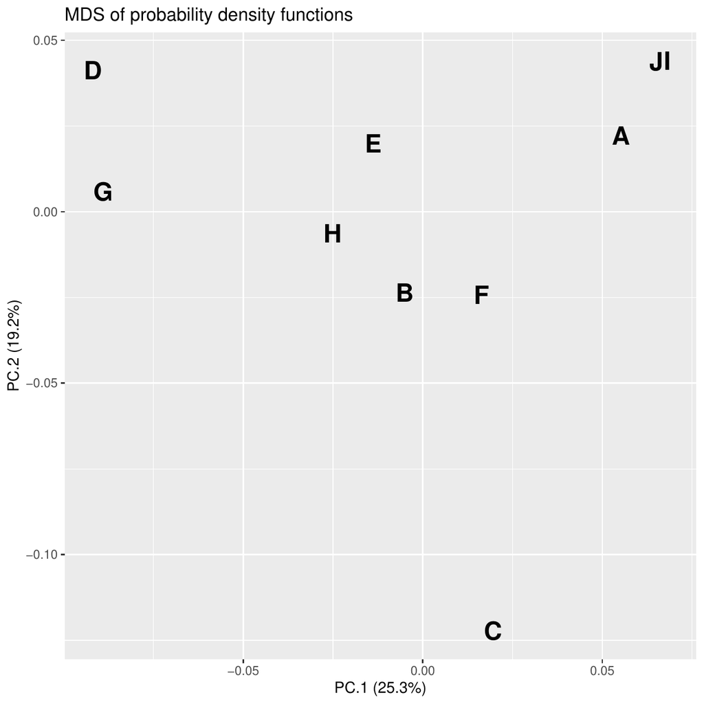

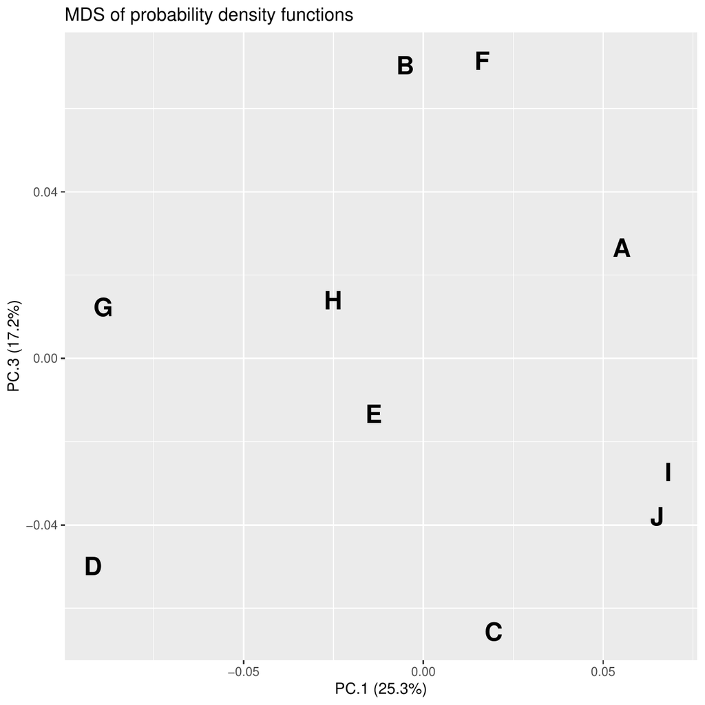

Figure 2: MDS of densities on sensory data (part of `roses` data frame): the first three principal coordinates.

Thus, from this interpretation of the PCs, we can describe the classes of rose bushes that can be constituted in view of their proximities *vs.* distances visualized in Figure 2. For example, the roses of the class $\left\{A, I, J \right\}$ have thick foliage compared to those of the class $\left\{D, G \right\}$, the rose bush $C$ is very asymmetrical compared to the other rose bushes, the rose bushes of the class $\left\{B, F \right\}$ have a top sided shape.

In order to obtain the correlations between the scores and the standard deviations, we set the optional argument `moment` to `"sd"` as in the following example. The other possible values of this argument include `"var"` (variances), `"skewness"`, `"cor"` (correlations for multivariate densities).

```r
> interpret(resultmds, moment = "sd")
```

```r
Pearson correlations between scores and moments
        PC.1  PC.2  PC.3
sd.Sha  0.67  0.21 -0.49
sd.Den -0.01  0.77  0.11
sd.Sym -0.13 -0.44  0.76
Spearman correlations between scores and moments
        PC.1  PC.2  PC.3
sd.Sha  0.50  0.45 -0.58
sd.Den  0.15  0.64 -0.08
sd.Sym -0.26 -0.76  0.75
```

Some of the correlations between the PCs and the standard deviations of the variables seem high. Reminding that the PCs are related to means, these correlations are therefore clues of links between standard deviations and means of the variables. We, therefore, represent roses using their means and standard deviations (Figure 3). We highlight that the standard deviations/variances used to assess discordance between assessors tend to be smaller when the products subjected to evaluation on a nine-level scale were awarded marks at the ends of the scale. This result which is actually quite intuitive, obtained by the use of MDS on probability density functions, would have been difficult to demonstrate if the means and standard deviations/variances had been analyzed separately.

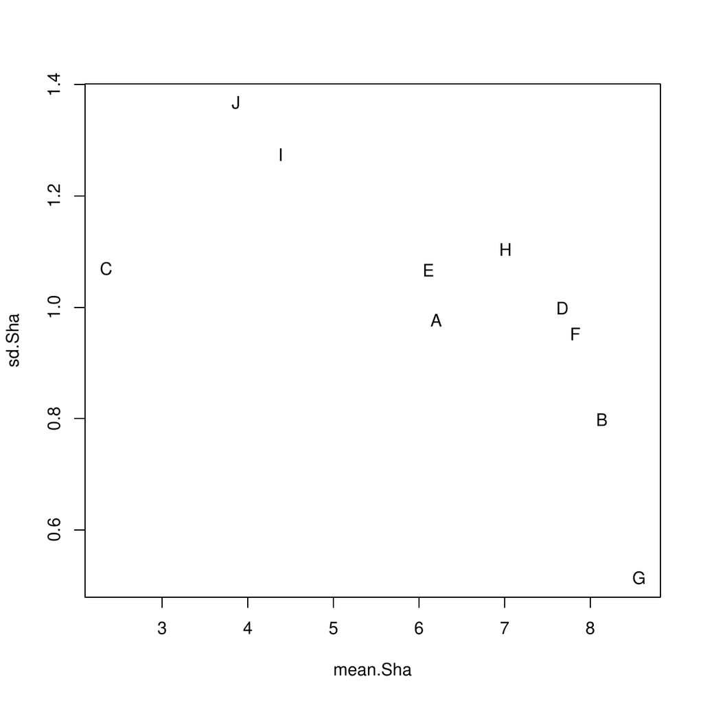

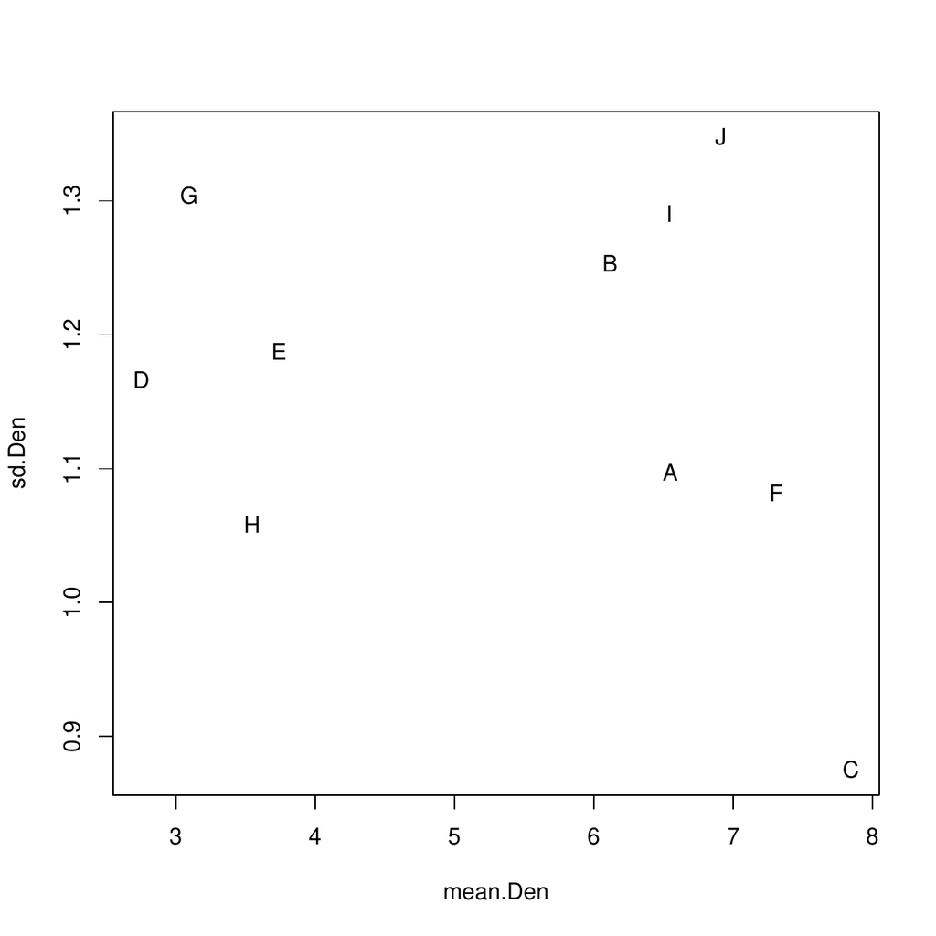

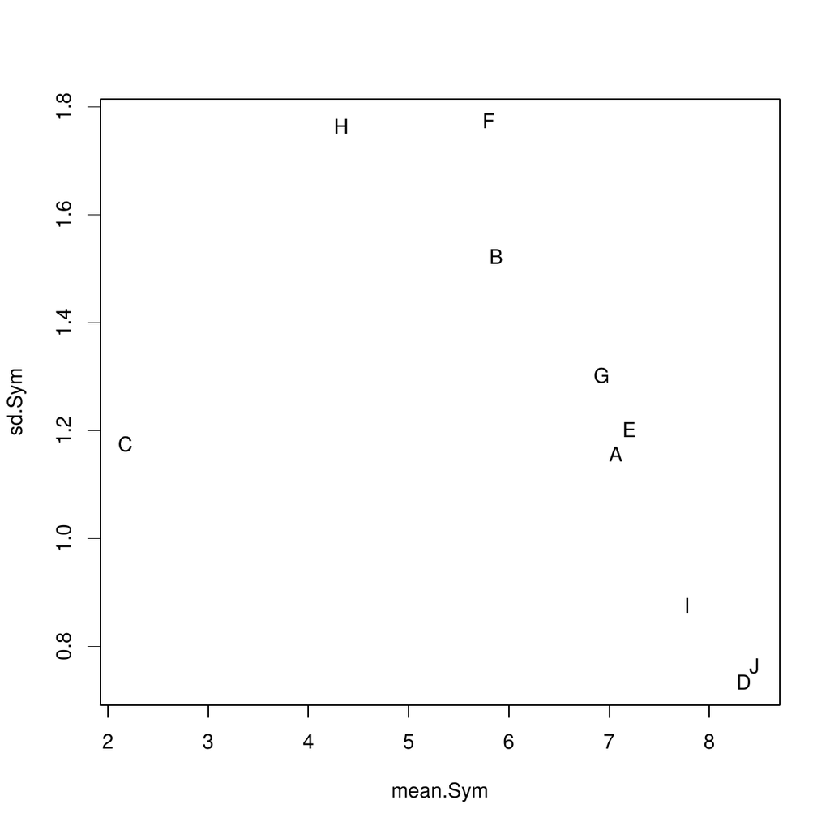

Figure 3: MDS of densities on sensory data (part of `roses` data frame): relationships between means and standard deviations of the variables.

## 5 HCA of densities

As for MDS, the `fhclustd` function of the *dad* package implementing hierarchical cluster analysis of probability density functions is a direct application of `hclust`, the corresponding function of R. So it is briefly recalled, and we put the emphasis on the interest of coupling the implementation of MDS with HCA in order to interpret more easily the clusters resulting from HCA.

### 5.1 Brief description of the method and of its outputs

HCA deals with the same kind of data as the MDS technique, namely: $T$ probability density functions and $(\delta_{ts})_{1\leq t,s\leq T}$ the distances/divergences between each pair of them. Its purpose is to build a series of nested partitions that can be visualized by means of a dendrogram (Figure 4). An agglomerative building algorithm starts with a partition consisting of $T$ clusters (one density per cluster) then “*it repeats merging the closest pair of clusters according to some similarity criteria until all the data* (densities in our context) *are in one cluster*” (Gan et al. 2007). The criteria are built on dissimilarities between sets of densities, which themselves derive from $(\delta_{ts})_{1\leq t,s\leq T}$ obtained as follows:

```r
> resulthca <- fhclustd(rosesf, gaussiand = FALSE, distance = "l2")
> round(resulthca$distances, digits = 2)
```

```r
     A    B    C    D    E    F    G    H    I
B 0.14
C 0.19 0.18
D 0.19 0.18 0.21
E 0.14 0.14 0.18 0.14
F 0.14 0.09 0.18 0.18 0.15
G 0.19 0.15 0.20 0.16 0.17 0.17
H 0.15 0.12 0.17 0.16 0.12 0.14 0.14
I 0.12 0.15 0.18 0.18 0.14 0.15 0.18 0.15
J 0.15 0.16 0.19 0.19 0.15 0.16 0.19 0.15 0.08
```

The dendrogram (Figure 4 ) is obtained by the following instruction:

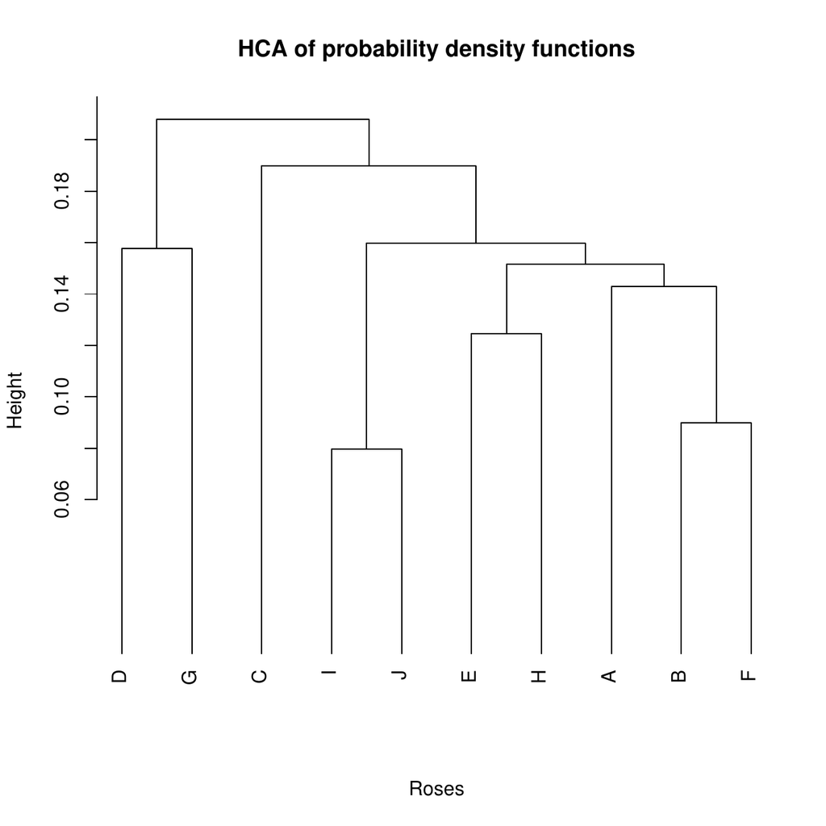

Figure 4: HCA of densities on sensory data (part of `roses` data frame). The y-axis indicates the distance at which the clusters are merged: the lower this distance is, the more the rosebushes of the clusters are similar.

```r
plot(resulthca, xlab = "Roses", sub = " ", hang = -1)
```

### 5.2 HCA and MDS on the same densities

In the *Interpretation of `fmdsd` outputs* section, we described the method used to give meaning to the principal coordinates based on the moments of the variables, from which we deduced the meaning of the clusters of roses constituted using the scores of MDS.  
This illustrates the process we propose to follow in practice:

- Carry out HCA and deduce a partition in HCA-clusters;
- Carry out MDS and constitute MDS-classes;
- Specify the characteristics of the MDS-classes according to the moments of the variables;
- Describe HCA-clusters which are similar to MDS-classes;
- Describe the other HCA-clusters by using, when possible, the MDS-scores of the groups making up these clusters.

## 6 DA of densities

With the notations introduced at the beginning of the section *Multi-group data: examples and organization*, the aim of discriminant analysis of densities (Boumaza 2004) is to predict the value of $G$ (Table 2) for the occasion $T+1$ represented by the density $f_{T+1}$, knowing $n_{T+1}$ observations of the random vector $X_{T+1}$, which are stored in $\mathbf{X}_{T+1}$ (Table 1).

For each $k=1,\ldots,K$, we denote by $g_k$, the density representing the class $k$ of $G$. The predicted value is:
$$\label{ruledistance}
\widehat{k} = \arg\ \min_{1\leq k\leq K} D(f_{T+1}, g_k)\text{,} \tag{4}$$
where $D$ is a distance index between densities (*Distance/divergence between densities* section). The data corresponding to the density $g_k$ are those corresponding to the $T_k$ densities $f_t$ belonging to the class $k$ of $G$. In Appendix F, we specify the possible procedures for calculating the densities $g_k$ and highlight the link between DA of densities and the linear discriminant analysis (*MASS*) in the homoscedastic Gaussian case.

The *dad* package performs all the calculations required to obtain the predicted value through the `fdiscd.predict` function whose first two arguments, `x` and `class.var`, control the input data. It includes the arguments `distance` and `crit`, which respectively set the distance and the densities $g_k$ (Appendix F). It also includes the arguments `gaussiand` and `windowh`, which control the method of density estimation. The `fdiscd.predict` function returns an object of `S3` class `fdiscd.predict`, which is a list consisting of prior and predicted values corresponding to each $f_t$, a confusion matrix, the distances $(d_{tk})$ between the $f_t$’s and the $g_k$’s, and proximities. These are calculated from the inverse of the distances in such a way that their sum is 1, but they are not probabilities and are useful for a quick comparison of the distances.

In addition, the package calculates the misclassification ratio for the occasions for which the prior class of $G$ is known through the `fdiscd.misclass` function. This ratio is computed by using the leave-one-out method on the $T$ occasions, and the lower it is, the better the prediction of the variable $G$ by the data $\mathbf{X}$. This function is based on arguments almost identical to those used by the `fdiscd.predict` function. It also generates similar outputs, grouped into an object of the `S3` class `fdiscd.misclass`. However, these two functions differ in the method used to calculate the distances $(d_{tk})$: if $f_t$ belongs to the $k$-th class of $G$, the data corresponding to $f_t$ are not included in the data used to estimate $g_k$. This function is useful for empirical investigations in order to identify the optimal values of the arguments minimizing the misclassification ratio. These values are then used by the `fdiscd.predict` function for prediction of the $G$ class of an occasion of unknown class.

### 6.1 First example: Castles / Stones

```r
> data("castles.dated")
> levels(castles.dated$periods$period) <- c("1", "2", "2", "2", "3", "3")
> castlesfh <- folderh(castles.dated$periods, "castle", castles.dated$stones)
```

The `fdiscd.misclass` function is used to calculate the misclassification ratios (global and per class).

```r
> fdiscd.misclass(castlesfh, class.var = "period", distance = "l2")
```

```r
misallocation ratio:  0.3382353
           predicted.class
prior.class  1  2  3 total misalloc
      1     10  3  0    13    0.231
      2      5 24  8    37    0.351
      3      0  7 11    18    0.389
      total 15 34 19    68
---------------------------------------------------------------
 castle prior.class predicted.class misclassed
      1           1               1      FALSE
      2           1               1      FALSE
      3           1               2       TRUE

    ...

    131           2               2      FALSE
    133           3               2       TRUE
    135           2               3       TRUE
    136           2               1       TRUE
```

In order to empirically calibrate the different arguments of the function, the previous operation is repeated, choosing other values for the arguments. If the `gaussiand` argument is set to `TRUE`, the smallest global misclassification ratio is 34% (Table 6) and is obtained for `crit = 1`, the default value for this argument, and for `distance = "l2"` or `"hellinger"`.

Estimating the densities by the Gaussian kernel method by setting `gaussiand = FALSE`, with the bandwidth defined by ((2)) and ((3)), increased the global misclassification ratio to 40%. If we consider the same proportionality coefficient $h$ in the formula ((2)), that is
$$\label{hwindowh}
\mathbf{h}_t=h \, \widehat{\mathbf{V}}_t^{1/2}, \tag{5}$$
by setting the argument `windowh` of the function `fdiscd.misclass`, we empirically obtain a value of $h$ that minimizes the misclassification ratio. For this purpose, we calculate the misclassification ratio for different values of `windowh` (Table 7). Note that an optimal empirical value is about `windowh = 0.6`, with a misclassification ratio of 32%. One of the best empirical parametrizations of the `fdiscd.predict` function would be `gaussiand = FALSE`, `windowh = 0.6`, and `crit = 1`.

Table 6: Castles/Stones. Misclassification ratio assuming densities to be Gaussian and parametrically estimated, depending on the value of the `crit` argument used to select the type of $g_k$ density (Appendix F).

| `crit` | 1 | 2 | 3 |
| --- | --- | --- | --- |
| Ratio | 0.34 | 0.56 | 0.40 |

Table 7: Castles/Stones. Misclassification ratio for densities estimated by the Gaussian kernel method, depending on the value of the `windowh` argument, the proportionality coefficient setting the bandwidth.

| `windowh` | 0.1 | 0.2 | 0.3 | 0.4 | 0.5 | 0.6 | 0.7 | 0.8 | 0.9 |
| --- | --- | --- | --- | --- | --- | --- | --- | --- | --- |
| Ratio | 0.56 | 0.44 | 0.38 | 0.38 | 0.37 | 0.32 | 0.32 | 0.35 | 0.34 |

The misclassification ratios are disappointing. Thus, the method was used only as an indication to date the castles and its results were cross-checked with other established facts from other historical sources (Rudrauf and Boumaza 2001).

### 6.2 Second example: Rosebushes/Leaves

Let us consider the agronomic data (Section *Multi-group data: examples and organization*, Example 2). We consider only the continuous variables characterizing the leaves, that is, leaving out the discrete variable “number of leaflets”. As in the first example, we carry out discriminant analysis by applying the `fdiscd.misclass` function for different parameter values. Table 8 gives the classification error rates for the three criteria and some values of the proportionality parameter. One of the best combinations of parameter values would, therefore, be `crit` = 3 and `windowh` = 0.2. The error rate is 0.032, which is clearly better than the result obtained with the archaeological data of the first example. If the same method is applied to all variables, including “number of leaflets”, the error percentage is zero for `crit` = 3 and `windowh` = 0.3.

In these two previous examples, it should be noted that the search for an optimum value of the parameter `windowh` has the disadvantage of being carried out by trial and error and is a time-consuming procedure.

Table 8: Rosebushes/Leaves. Misclassification ratio for the three criteria and different values of the proportionality parameter `windowh`, the densities being estimated by the Gaussian kernel method.

| `windowh` | `crit` = 1 | `crit` = 2 | `crit` = 3 |
| --- | --- | --- | --- |
| 0.1 | 0.742 | 0.806 | 0.129 |
| 0.2 | 0.452 | 0.677 | **0.032** |
| 0.3 | 0.226 | 0.452 | 0.097 |
| 0.4 | 0.129 | 0.226 | 0.097 |
| 0.5 | 0.097 | 0.129 | 0.161 |
| 0.6 | 0.097 | 0.129 | 0.161 |
| 0.7 | 0.065 | 0.129 | 0.194 |
| 0.8 | 0.065 | 0.097 | 0.226 |
| 0.9 | 0.065 | 0.097 | 0.226 |

## 7 Practical advice

### 7.1 Data management

The functions `folder` and `as.folder` play a central role in the creation of objects handled by the functions `fmdsd` (MDS on continuous data), `mdsdd` (MDS on discrete data), `fhclustd` (HCA on continuous data), and `hclustdd` (HCA on discrete data). The functions `folderh` and `as.folderh` play the same role in DA context: `fdiscd.misclass` and `fdiscd.predict` in the continuous case, or `discdd.misclass` and `discdd.predict` in the discrete case.

It is advisable for the user to know how to use them, especially as their handling is quick and easy (Appendix C).

### 7.2 Computation times

The computation times of the functions of *dad* depend mainly on the computation time of the distances between groups in MDS and HCA contexts or between groups and classes in the DA context. The longest times are achieved when the densities are estimated by the kernel method (*Calculation of $L^2$ distances between continuous non-Gaussian densities estimated by the kernel method* section). When applying the function `matdisl2` with the option `method = "kern"` on the archeological data (Example 1 of Appendix G), the computation time is approximately five times greater than when `method = "gaussiand"`.

Among the main functions of *dad*, the most time-consuming one is undoubtedly `fdiscd.misclass` when its `gaussiand` argument is set to `FALSE`. That is, the densities are non parametrically estimated. For example, applying this function to archaeological data with `gaussiand = TRUE` takes less than one second while it takes approximately 30-40 seconds with `gaussiand = FALSE` (Example 2 of Appendix G). Thus, we recommend doing tests on small datasets when working on non-Gaussian continuous data.

### 7.3 Choice of distance

The choice of a distance index depends above all on the modeling hypotheses: discrete or continuous data. If they are discrete *dad* proposes five indices (Table 4). If they are continuous, it proposes five indices in the Gaussian case (Table 5) and only one for non-Gaussian data, which is the $L^2$ distance combined with the estimation of the densities by the Gaussian kernel method.

The distance indices of discrete or Gaussian densities are compared on particular examples in the context of HCA (Appendix A) or DA (Appendix B). It is shown that depending on the technique used and the criterion for measuring the quality of the results, a distance index can be better than another for a set of data and worse for another set. Thus, in the discrete or Gaussian cases, if there is no a priori choice of distance index, we suggest an empirical approach. As the computation times are reasonable, we perform the desired analysis by experimenting with each of the distance indices, then choose the distance index according to one of the two criteria given by *dad*.

For DA, it is the misclassification ratio obtained by the one-leave-out procedure by using the function `fdiscd.misclass`. We should choose the distance index which gives the lowest misclassification ratio.

For MDS, it is the interpretation of principal coordinates in terms of marginal distributions (discrete densities) or moments (continuous densities) using the function `interpret`. We should choose the distance index which gives the highest correlations between principal coordinates and marginal distributions or moments. For HCA, we combine it with the MDS method (*HCA and MDS on the same densities* subsection) and, therefore, we refer to the above to choose the distance index.

## 8 Discussion and concluding remarks

The classic statistical methods as multidimensional scaling (MDS), hierarchical clustering analysis (HCA), and discriminant analysis (DA) operate on data which are rows of a data frame. They are available in the R packages [*stats*](https://CRAN.R-project.org/package=stats), [*MASS*](https://CRAN.R-project.org/package=MASS) (Venables and Ripley 2002), [*ade4*](https://CRAN.R-project.org/package=ade4) (Dray et al. 2007), [*FactoMineR*](https://CRAN.R-project.org/package=FactoMineR) (Lê et al. 2008), [*cluster*](https://CRAN.R-project.org/package=cluster) (Maechler et al. 2019). The *dad* package presented in the manuscript generalizes them to data that are organized into groups or occasions. The graphics produced by MDS, the clusters constituted by HCA, or the predicted class provided by DA, concern the occasions and not the individuals who constitute them.

These methods are multivariate data analysis, but they can also be seen as functional data analysis since they operate on multivariate functions estimated from multivariate data. They are theoretically similar to some functional statistical methods implemented in *fda.usc*, *fda*, and *fdadensity* packages. The main difference is in the type of data processed. The functional statistical methods deal with functions of only one or two variables, while the main functions of *dad* can deal with more.

These methods can also be seen as compositional data analysis. Indeed, compositional dataset provides portions of the total (Aitchison 1986) and the R packages *compositions*, *Compositional*, and *robCompositions* are devoted to such data by implementing many descriptive or graphical techniques and models. Regarding the packages *Compositional* and *robCompositions*, their modeling approach is far enough from our approach to be addressed in this discussion, while the package *compositions* presents similarities with our work which we detail in Appendix H. In the case of a univariate discrete density, the differences concern the method of interpreting the graphical outputs provided by `princomp` of *compositions* and `mdsdd` of *dad* even if we get fairly similar graphics (see the example of Appendix H). In the multivariate case, *dad* takes into account marginal distributions of orders 1 and 2 (or more), while in the current version of *compositions*, only marginal distributions of order 1 are taken into account.

The most recent version of the *dad* package implements functions which operate on discrete data. It also extends the three previous methods to a mixture of numerical and categorical data by transforming the numerical data into categorical data. It is done by dividing the range of each numerical variable into intervals using the function `cut.folder`, an extension of the function `cut` to several variables of a folder.

In addition, the last versions of functions implementing MDS and HCA apply to data stored in a data frame and not only to data stored in a folder.

The following development work is also planned:

- Automation of the empirical search for the proposed proportionality coefficient in the formula ((5)), considered optimal (in at least some ways) in the context of discriminant analysis;
- Automation of the empirical search for a similar coefficient suitable for use in multidimensional scaling as proposed by Yousfi et al. (2015) in principal component analysis context.

## 9 Summary

When we work on multidimensional multi-group data and are interested in the groups and not in the individuals who make up these groups, we want to have statistical methods and computer tools making it possible to describe these groups. The *dad* package is devoted to this.

It mainly provides elaborate functions which implement multivariate techniques such as *multidimensional scaling*, *hierarchical classification analysis*, or *discriminant analysis* on such groups. Moreover, in order to help users in reading the outputs of these techniques, *dad* provides functions for interpreting the results.

It provides datasets which illustrate such data and easy-to-use functions which allow to (i) manage multi-group data by associating a data frame with each group, (ii) compute the distances between groups based on the mathematical concept of probability distribution/density, and (iii) secondarily compute elementary statistics by group as for example frequency distributions and moments.

It defines new data structures called folders (`folder`, `folderh`, `foldermtg`) and provides specific tools to manage them, such as selecting or deleting columns from a `folder`, converting numeric columns of a `folder` to factors. The most noticeable among them allows to easily import into R plant architectures encoded in `mtg` files and, thus, have R packages available to analyze the imported data.

## 10 Acknowlegments

The authors thank Gilles Hunault and Julie Bourbeillon, the Associate Editor, and the reviewers for their valuable comments and contributions to this work.

## 11 Appendix A: HCA and distance index

We compare three distance indices in the HCA context with a small, simple example originating from an exchange with an anonymous reviewer of a previous version of the manuscript by comparing the $L1$ and $L2$ distances and the symmetrized divergence of Kullback-Leibler. In his review, he made a severe criticism of the $L2$ distance, which was the unique distance proposed in the first versions of the *dad* package: “*Let* $f$ *a uniform density in the interval* $[0,\ 1]$, *and* $g$ *also uniform in* $[0,\ 0.90]$. *Clearly, from the point of view of* $g$*, it is impossible to reach values in the interval* $(0.90,\ 1]$ *and so, these two densities are not neighbors.*” Indeed, the $L1$ and $L2$ distances and the symmetrized Kullback-Leibler divergence (KL) are:
$$L1(f,g) = 0.20,\ \ L2(f,g) = 0.33,\ \ KL(f,g) = \infty,$$
so $KL (f, g)$ reflects this impossibility of reaching all the values of $f$ from $g$, unlike $L1$ and $L2$, which consider them to be relatively close to each other.

However, if we add the other two densities $v$ and $w$, uniform on $[0,\ 0.10]$ and $[0, 0.11]$, and if our objective is to obtain either a partition of $f$, $g$, $v$, and $w$ in 2 classes, or an approximate representation on a plane of these 4 densities, the choice of $L1$ or $L2$ is more informative than $KL$ (Table 9) because with the first two distances, we would easily group $f$ and $g$ on one side and $v$ and $w$ on the other side, whereas with KL all distances are infinite.

Table 9: $L1$, $L2$, and symmetrized Kullback-Leibler distance/divergence between the uniform probability densities $f=U([0, 1])$, $g=U([0, 0.9])$, $v=U([0, 0.10])$, and $w=U([0, 0.11])$.

| L1 |  |  |  |  | L2 |  |  |  |  | KL |  |  |  |  |
| --- | --- | --- | --- | --- | --- | --- | --- | --- | --- | --- | --- | --- | --- | --- |
|  | $f$ | $g$ | $v$ | $w$ |  | $f$ | $g$ | $v$ | $w$ |  | $f$ | $g$ | $v$ | $w$ |
| $f$ | 0 | 0.20 | 1.80 | 1.78 | $f$ | 0 | 0.33 | 3.00 | 2.84 | $f$ | 0 | $\infty$ | $\infty$ | $\infty$ |
| $g$ |  | 0 | 1.78 | 1.76 | $g$ |  | 0 | 2.98 | 2.82 | $g$ |  | 0 | $\infty$ | $\infty$ |
| $v$ |  |  | 0 | 0.18 | $v$ |  |  | 0 | 0.95 | $v$ |  |  | 0 | $\infty$ |
| $w$ |  |  |  | 0 | $w$ |  |  |  | 0 | $w$ |  |  |  | 0 |

Our belief is that the choice of a distance between groups cannot be made in the absolute. It is better to specify a criterion for choosing the distance, which makes sense in the context of the method used, such as percentage of inertia explained in MDS ((Delicado 2011)), or in the context of the data analysed. In the *Practical advice* section, we suggest two other criteria.

## 12 Appendix B: DA and distance index

In the two examples of *DA of densities* section, the data were not considered plausibly Gaussian and the distance used is the $L^2$ distance, the only distance computable in *dad* which is suitable for this type of data. In this appendix, we are interested in other types of data and in the misclassification ratios according to the distance index used (*Distance/divergence between densities* section).

### 12.1 Simulated discrete data

Let $p_1={\cal P}(\lambda_1)$ and $p_2 = {\cal P}(\lambda_2)$ be two Poisson distributions with respective parameter $\lambda_1 = 1$ and $\lambda_2 = 2$ and $S_1$ and $S_2$ respective simulated samples of size 30. We simulate a sample $S$ of size 10 according to the distribution $p_1$, we calculate the dissimilarities $d_1$ and $d_2$ between this sample and each of the samples $S_1$ and $S_2$, then we compare $d_1$ and $d_2$. We would expect $d_1$ to be less than $d_2$ since the samples $S$ and $S_1$ are from the same population. Thus, if $d_1> d_2$ we consider that the sample $S$ is misclassified. We repeat the previous scenario 1000 times and then calculate the misclassification ratio.

The results obtained for the same 1000 samples and each of the distance indices of Table 4 are in column (a) of Table 10. Then we proceed in the same way with 1000 samples of the distribution $p_2$; the misclassification ratios are in column (b).

Table 10: Poisson distributions. Misclassification ratios of 1000 samples from $p_1={\cal P}_1$ (a) or from $p_2={\cal P}_2$ (b). The instructions for R allowing the calculation of the ratios corresponding to the symmetric chi-square index are given in the last subsection. The other ratios are obtained by means of the corresponding distance while keeping the same simulation seed.

| Distance index | (a) | (b) |
| --- | --- | --- |
|  | Misclassification ratio | Misclassification ratio |
|  | of 1000 samples from $p_1$ | of 1000 samples from $p_2$ |
| Symmetric chi-square | 0.073 | 0.183 |
| Hellinger | 0.064 | 0.188 |
| Jeffreys | 0.049 $(600^{*})$ | 0.139 $(643^{*})$ |
| Jensen-Shannon | 0.139 | 0.269 |
| Lp | 0.079 | 0.172 |
|  | (*) number of samples $S$ at infinite distance from samples $S_1$ or $S_2$ |  |

We notice that for the Jeffreys divergence, the number of samples $S$ at infinite distances from $S_1$ or $S_2$ is very large, which makes it inefficient at discriminating between samples.  
We carried out several simulations as in the previous procedure to compare the distances. We did not find any stability in the order of distances according to the misclassification ratios.

### 12.2 Simulated Gaussian data

As for the discrete case, these distance indices are compared in a simplified context of discriminant analysis using the same procedure. Let $p_1$ and $p_2$ be the two Gaussian distributions $N(0,1)$ and $N(1,4)$.

Table 11: Gaussian distributions. Misclassification ratios of 1000 samples from $p_1 = N(0,1)$ (a) or from $p_2 = N(1,4)$ (b). The R instructions are similar to those of Poisson samples. It suffices to change the function `rpoi` to `rnorm` with the appropriate parameters. In these simulations, the seed is set to 123.

| Distance index | (a) | (b) |
| --- | --- | --- |
|  | Misclassification ratio | Misclassification ratio |
|  | for 1000 samples from $p_1$ | for 1000 samples from $p_2$ |
| Hellinger | 0.020 | 0.051 |
| Jeffreys | 0.018 | 0.043 |
| L2 | 0.034 | 0.040 |
| L2N | 0.026 | 0.111 |
| 2-Wasserstein | 0.007 | 0.169 |

The results are given in Table 11. We notice that for the samples from $N (0,1)$ (a), the distance giving the best rate is the Wasserstein distance. On the other hand, it is the worst for the samples from $N (1,4)$ (b).

We carried out several simulations and the conclusion is word for word the same as that of the discrete case with the Poisson distributions.

These results lead us to suggest choosing a distance index based on the minimum misclassification ratio in the subsection *Choice of distance* of *Practical advice* Section.

### 12.3 Computation of the misclassification ratios of Table 10 or 11

The following R instructions are used to compute the misclassification ratios in DA context with samples from Poisson distributions according to the symmetric chi-square distance index of Table 10. The instructions for computing the other ratios of Table 10 and the ratios of Table 11 are given in supplementary material.

```r
  > n <- 30
  > ne <- 10
  > nrep <- 1000
  > l1 <- 1
  > l2 <- 2
  > #
  > nmisclass1 <- 0
  > set.seed(135)
  > e1 <- rpois(n, lambda = l1)
  > e2 <- rpois(n, lambda = l2)
  > for(index in (1:nrep))
  +   { x <- rpois(ne, lambda = l1)
  +   d1 <- ddchisqsym(x,e1)
  +   d2 <- ddchisqsym(x,e2)
  +   if(d1 > d2) nmisclass1 <- nmisclass1 + 1
  +   }
  > misclassratio1 <- nmisclass1 / nrep
  > print(misclassratio1)
```

```r
  [1] 0.073
```

```r
  > nmisclass2 <- 0
  > set.seed(135)
  > e1 <- rpois(n, lambda = l1)
  > e2 <- rpois(n, lambda = l2)
  > for(index in (1:nrep))
  +   { x <- rpois(ne, lambda = l2)
  +   d1 <- ddchisqsym(x,e1)
  +   d2 <- ddchisqsym(x,e2)
  +   if (d1 < d2) nmisclass2 <- nmisclass2 + 1
  +   }
  > misclassratio2 <- nmisclass2 / nrep
  > print(misclassratio2)
```

```r
  [1] 0.183
```

## 13 Appendix C: some useful functions on data folders

The *dad* package uses objects of class `folder` or `folderh`. These objects are lists of data frames having particular formats.

### 13.1 Introductory example

Let us consider the archaeological data introduced in *Multi-group data: examples and organization* section. The data that Jean Michel Rudrauf (Rudrauf and Boumaza 2001) submitted to us was in the form of a paper binder, each sheet of which corresponds to a castle (Figure 5).

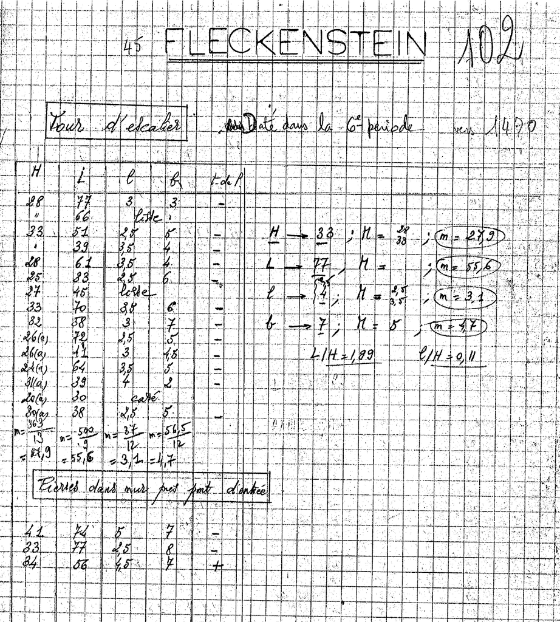

Figure 5: The data patiently collected by Jean Michel Rudrauf corresponds to the castle of Fleckenstein. Its number identification is 102. It was built around 1470 i.e. in the sixth period. The measurements are `H: height`, `L: width`, `l: edging` and `b: boss`. There are 10 stones whose measurements are complete: 7 stones belong to the staircase tower (*Tour d’escalier*) and 3 stones belong to a wall located near the entrance of the castle (*Pierres dans mur près pont d’entrée*). The corner stones designated by the symbol (a) in column `H`, are excluded from the study.

So for each castle we have:

- a name,
- an identification number,
- a building period (sometimes even a year) if it is known,
- the p = 4 measurements of a sample of stones.

A most natural and least redundant way for entering such data is to create:

- one data frame per castle. This data frame with `p` columns is named by the identification number of the castle and contains the measurements of the stones. Its number of rows corresponds to the number of stones whose all measurements are available.
- a data frame whose rows are the castles and whose columns correspond to the name, the identifier and the building period.

From there, we choose to suggest suitable data structures for multi-group data and propose management and calculation tools adapted to these data structures. This is exemplified below.

The archaeological data are stored in the list `castles.dated` of two data frames. The data frame `castles.dated$periods` consists of `T=68` rows (castles) and 2 columns: `castle`, the castle identifier, and `period`, the building period which is a factor with 6 levels. The second data frame `castles.dated$stones` consists of 1262 rows (stones) and 5 columns: 4 numeric characteristics of the stones (`height`, `width`, `edging`, and `boss`) and 1 factor `castle` with 68 levels, which gives the identifier of the castel to which belongs each stone. The implementation of DA requires carrying out calculations not only on all the stones of each castle but also on all the stones of all the castles of each period. To do this, we can store the stones in a data frame made up of 6 columns obtained by adding a column `period` to the file `castles.dated$stones`. Thus, all the stones of a castle have the same `period` value. In order to avoid this redundancy in data entry and management, we propose to store the two files `castles.dated$stones` and `castles.dated$periods` as well as the key `castle` which relates them, in a `folderh` that is a list of two data frames related by a key. The procedure for doing this is given in the paragraph *First example: Castles/Stones* of *DA of densities* section.

Now consider only the `castles.dated$stones` file. To implement both DA and MDS, it is necessary first to calculate and store the vectors of means and the covariance matrices of the `p=4` numeric variables for each castle, then to use the results in the calculation of the distances between each pair of castles. The calculations of means and covariances by castle can be carried out directly from the five-column data frame `castles.dated$stones` using, for example, the following R functions: `colMeans`, `var`, and `by`. In order to facilitate the extraction of data relating to a particular castle and control the data entry, or to check pieces of the computer program, we organize the data in a folder that is a list of `T` four-column data frames (one data frame per castle), and we extend the `mean` and `var` functions so that they apply to such a data structure and return results as lists. So if `x` is the name of the folder, `x[[t]]` is the data frame which contains the data of the castle `t`, `mean(x)[[t]]` is its vector of means and `var(x)[[t]]` is its covariance matrix. We find that by doing so, it is also easier to remember the names and contents of these objects when writing computer programs.

### 13.2 Objects of class `folder`

Such objects, lists of data frames which have the same column names, are created by the `folder` function, from two (or more) data frames, say `x1` and `x2`, as follows: `folder(x1, x2)`.

Optional argument `cols.select` defines the way in which the columns of the two data frames are selected: common columns only (`cols.select = "intersect"`) or all the columns (`cols.select = "union"`). For the `"union"` option, if the data frames do not have exactly the same column names they are complemented by `NA`’s.

The functions `mean.folder` (or simply `mean`), `skewness.folder`, and `kurtosis.folder` applied to the object `x` of the class `folder`, respectively return the list of the vectors of means, skewnesses, and kurtosises of the numeric columns of the elements of `x`. The functions `var.folder` and `cor.folder` return the list of the covariance and correlation matrices. If the data frames of `x` contain non-numeric columns, these functions exclude these columns from the computation. If they contain only one numeric column, these functions return lists of numbers. Note that `map(x, colMeans)`, `map(x, cor)`, and `map(x, var)` return the same values as before, except in the presence of a factor column whose levels are numbers: `map(x, colMeans)` and `map(x, cor)` return an error while `map(x, var)` integrates the factor column in the covariance matrices.

Hence, in `folder` objects, the observed variables are the same on every occasion, unlike individuals which can be different from one occasion to the next. The particular case where individuals are the same on every occasion, corresponds to data defined as three-way data by Kiers (2000) in his essay on standardization of terminology for multiway analysis. In this particular case, it would be better to store the data in an object of class `array`.

### 13.3 Objects of class `folderh`

Such objects are hierarchical lists of data frames in which two successive data frames from the list are related by means of a key. We complete the presentation of the introductory example by a case with more than two data frames. For three data frames, say `df1`, `df2`, and `df3`, there are two keys: the first, say `key1`, describes the “1 to N” relationship between `df1` and `df2`, and the second, say `key2`, describes the “1 to N” relationship between `df2` and `df3`. The arguments of the `folderh` function are introduced in the following order: `df1`, `key1`, `df2`, `key2`, `df3`, and so on, if there are more than three data frames. An example of such object is given in Appendix D.

The function `as.data.frame` applied to such a hierarchical folder, say `fh`, whose constituent elements are listed above, has two main arguments: `key` (the name of a key of `fh`) and `elt` (the name of a data frame of `fh`) with the precision that the value of `elt` is located after the value of `key` in the list of arguments defining `fh`. In the case of two adjacent names, that is `key` = `key1` and `elt` = `df2` or `key` = `key2` and `elt` = `df3`, `as.data.frame` returns a data frame similar to any viewpoint to that returned by the `merge` function. If `key` = `key1` and `elt` = `df3`, the data frame returned by the `as.data.frame` function, say `dfr`, has the same rows as `df3`. The columns of `dfr` are those of the data frames `df3` and `df1`, and those corresponding to all the keys located between `key1` and `df3` in the list defining `fh`, noticing that the key columns are the first columns of `dfr`.

## 14 Appendix D: Import plant architectures encoded in `mtg` files

The result of this import procedure consists of an object of class `folderh` and uses an intermediate object of class `foldermtg`. Let us first specify what an `mtg` file is.

The topological structure of a plant is defined from its decomposition into elementary components and the connections between them (Godin and Caraglio 1998). In Figure 6, the plant is composed of 2 axes (one principal axis, `A1`, coming from the root and bearing one secondary axis, `A2`) and each axis is composed of internodes and peduncles: the principal axis is composed of seven internodes `I1`, ..., `I7` and one peduncle `F1` and the secondary axis is composed of three internodes `I8`, `I9` and `I10`. Among the computer file types used to store the topology of a plant, we are interested in `mtg` (multiscale tree graph) files which can be opened with a spreadsheet as LibreOffice-Calc, or Excel (Pradal and Cokelaer 2010). Breaking a plant into axes and breaking each axis into internodes create two “1 to N” relationships which can be stored in an object of class `folderh`. This hierarchical folder, say `fh`, is a list of three data frames `P` (set of 1 plant), `A` (set of 2 axes), and `I` (set of 10 internodes), and two keys `P` and `A`. It is the result of the following three R instructions which successively imports an mtg file into R, creates an object of the `S3` class `foldermtg`, and then creates `fh`.

```r
  > mtgfile <- system.file("extdata/plant2.mtg", package = "dad")
  > x2 <- read.mtg(mtgfile)
  > fh <- as.folderh(x2, classes = c("P", "A", "I"))
  > print(fh)
```

```r
  $P
        P Variety
  v01 v01 Starina

  $A
        P   A Length
  v02 v01 v02     30
  v07 v01 v07     12

  $I
        A   I Leaflet
  v03 v02 v03       3
  v04 v02 v04       3
  v05 v02 v05       5
  v06 v02 v06       5
  v08 v07 v08       5
  v09 v07 v09       5
  v10 v07 v10       7
  v11 v02 v11       7
  v12 v02 v12       5
  v13 v02 v13       3

  attr(,"class")
  [1] "folderh"
  attr(,"keys")
  "P" "A"
```

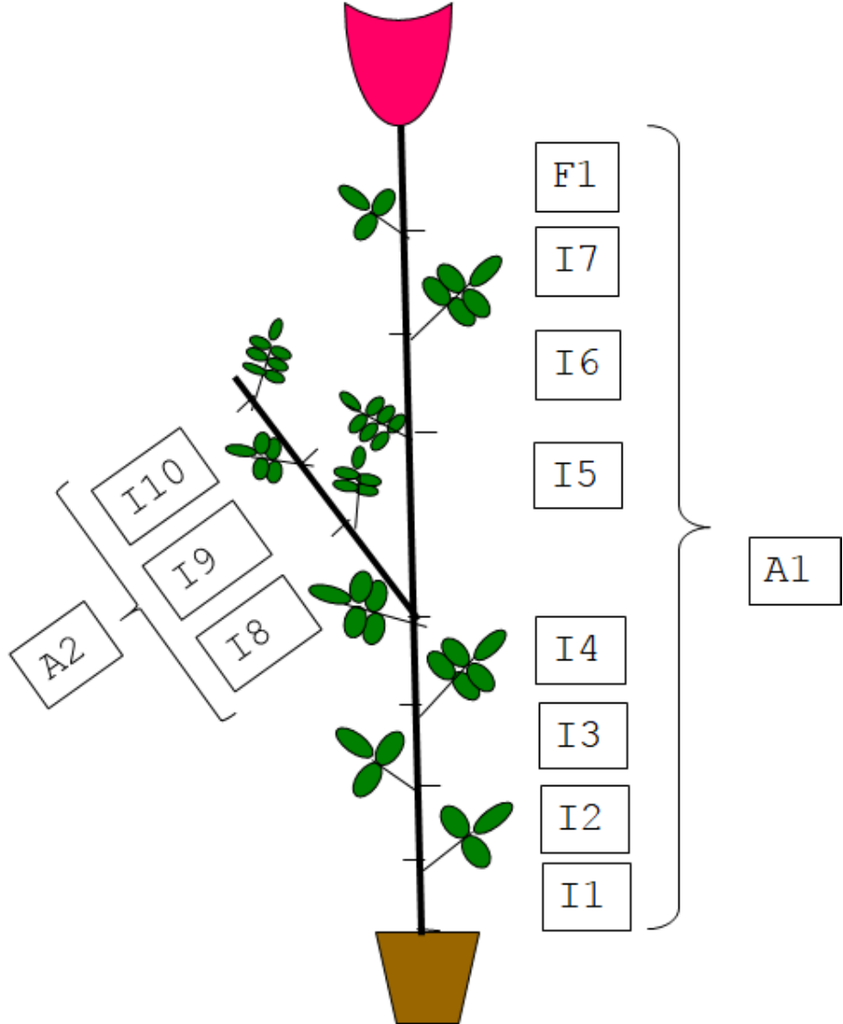

Figure 6: Decomposition of a plant (`P`) into axes (`A`), internodes (`I`), and peduncles (`F`).

Table 12: The first two columns correspond to the plant topology stored in an `mtg` file. The third column corresponds to the code of each component: the plant (P) is encrypted `v01`, etc.

| Biological component |  | File code |
| --- | --- | --- |
| `/P1` |  | v01 |
| $\wedge$`/A1` |  | v02 |
| $\wedge$`/I1` |  | v03 |
| $\wedge$`<I2` |  | v04 |
| $\wedge$`<I3` |  | v05 |
| $\wedge$`<I4` |  | v06 |
|  | `+A2` | v07 |
|  | $\wedge$`/I8` | v08 |
|  | $\wedge$`<I9` | v09 |
|  | $\wedge$`<I10` | v10 |
| $\wedge$`<I5` |  | v11 |
| $\wedge$`<I6` |  | v12 |
| $\wedge$`<I7` |  | v13 |
| $\wedge$`<F1` |  | v14 |

An object of class `foldermtg` is a list of data frames. It is only an intermediary to which the only function of R which can be applied to it is `as.folderh`. This, therefore, makes it possible to retrieve a hierarchical folder which consists of data frames, one data frame per type of biological components, on which one can operate statistical calculations by means of R functions.

## 15 Appendix E: Particular cases of the `fmdsd` function

We assume that the densities associated with the occasions are Gaussian. For particular values of the arguments `data.centered`, `data.scaled`, and `common.variance`, the outputs of the fmdsd function are similar to those returned by other functions.

### 15.1 `common.variance = TRUE`

The Gaussian densities are assumed with the same covariance matrix which is estimated using all data. Thus, the distances between the densities are reduced to the differences between their mean vectors (Table 5). The Euclidian distances between mean vectors computed by the R function `dist` are equal to that computed by the 2-Wasserstein distance between densities. In this case, the R function `cmdscale` applied on the mean vectors returns exactly the outputs of the `fmdsd` function.

### 15.2 `data.centered = TRUE`

The Gaussian densities are assumed with zero mean vectors. Consequently, the distances between the densities are reduced to the differences between their covariance matrices (Table 5). With the 2-Wasserstein distance, the distances between the densities are reduced to the Hilbert-Schmidt distances between the square root of the covariance matrices while the dual STATIS method (Lavit et al. 1994) uses Hilbert-Schmidt distances between the covariance matrices. In R, the calculations can partly be performed with the `DSTATIS` function of the *multigroup* package (Eslami et al. 2013; Eslami et al. 2020) or the `statis` function of the *ade4* package (Dray et al. 2007) after some transformation. However, the outputs of these two functions are completely different from those of the `fmdsd` function (*MDS of densities* Section): `fmdsd` focuses on the visualization of the occasions, while the other functions focus more on the visualization of variables or individuals.

### 15.3 `data.scaled = TRUE`

With the two previous special cases, we have shown that MDS on densities is a way to take into account globally the means, variances, and covariances of the occasions and, therefore, a form of generalization of separate analyses either on averages or on variances and covariances. The optional argument `data.scaled` is useful when the analyst is interested to focus only on the relationships between variables.

## 16 Appendix F: DA of densities and classic DA

### 16.1 Densities associated to the classes of the factor *G* defined on the occasions

In the functions `fdiscd.misclass` and `fdiscd.predict`, for each $k=1,\ldots,K$, the density $g_k$ representing the class $k$ of $G$ is estimated using a procedure selected by means of the argument `crit`. Recalling that the class $k$ contains $T_k$ densities $f_t$, the three procedures are defined as follows.

1. All samples related to the $T_k$ occasions of class $k$ are pooled and constitute a single sample, which is then used to estimate $g_k$.
2. If $\hat{f}_t$ estimates $f_t$, then $g_k$ is estimated by the mean value of the $T_k$ densities pertaining to the class $k$: $(1/T_k) \sum \hat{f}_t$.
3. The mean value of the previous $T_k$ densities is calculated by weighting each $\hat{f}_t$ by the size of its corresponding sample: $(1/\sum n_t)\ \sum n_t\hat{f}_t$.

The last two procedures are only available if the argument `distance` is set to `"l2"`. If there is only one occasion per class that is $T_k=1,\ \forall k$, the three procedures are the same. In this case, the data are those of the training step of classic DA. However, in the prediction step, we have to assign a group of individuals not individually but taken as a whole.

### 16.2 Homoscedatic Gaussian case

We assume that:

- the densities $f_t\ (t=1,\ldots,T)$ are Gaussian with the same covariance matrix $V$. We denote $f_t$ by $N(m_t,V)$;
- there is one density $f_t$ per class of $G$. So, there are $K=T$ classes, and the density of the class $k$ is denoted by $f_k$.
- the density $f_{T+1}$ is Gaussian $N(m_{T+1},V)$

We have to predict the class value of $f_{T+1}$ using the rule (4) and one of the distances from Table 5. For `distance = "wasserstein"`, we calculate the distances between the mean vectors $\|m_{T+1}- m_k\|_{I_p} \ (k=1,\ldots,T)$, and for the other distances we calculate the distances $\|m_{T+1}- m_k\|_{V^{-1}}\ (k=1,\ldots,T)$.  
In the homoscedastic Gaussian case, this makes DA of densities appear as a form of extension of linear discriminant analysis where the group of individuals to be predicted is summarized by the mean vector of the group.

## 17 Appendix G: Some computation times

All the following calculations are carried out using a laptop computer equipped with an i5 processor on the archaeological data. The stone characteristics are stored in the data frame `x.df`. Then, we create the corresponding folder `x.folder`.

```r
  > data(castles.dated)
  > x.df <- castles.dated$stones
  > x.folder <- as.folder(x.df, groups = "castle")
```

### 17.1 Example 1: Comparison of distance indices in the continuous case

The computation times of the inter-group distances are of the same magnitude when the densities are supposed Gaussian and parametrically estimated. Computations with the $L^2$ distance take about one second.

```r
  > system.time(matdistl2d(x.folder, method = "gaussiand"))
```

```r
         user      system     elapsed
         1.13        0.06        1.36
```

When the densities are estimated by the kernel method, the computation time is multiplied by about 5.

```r
  > system.time(matdistl2d(x.folder, method = "kern"))
```

```r
         user      system     elapsed
         6.38        0.14        6.53
```

### 17.2 Example 2: Computation time of the function `fdiscd.misclass`

We build the hierarchical folder `x.fh` corresponding to the archeological data. We first apply the function `fdiscd.misclass` with the option `gaussiand = TRUE` then with the option `gaussiand = FALSE`.

```r
  > x.fh <- folderh(castles.dated$periods, "castle", castles.dated$stones)
  > system.time(fdiscd.misclass(x.fh, class.var = "period", distance = "l2", gaussiand = TRUE))
```

```r
         user      system     elapsed
         0.16        0.02        0.17
```

```r
  > system.time(fdiscd.misclass(xfh, class.var = "period", distance = "l2", gaussiand = FALSE))
```

```r
         user      system     elapsed
        38.13        0.17       38.64
```

## 18 Appendix H: MDS on compositional data and compositional data analysis

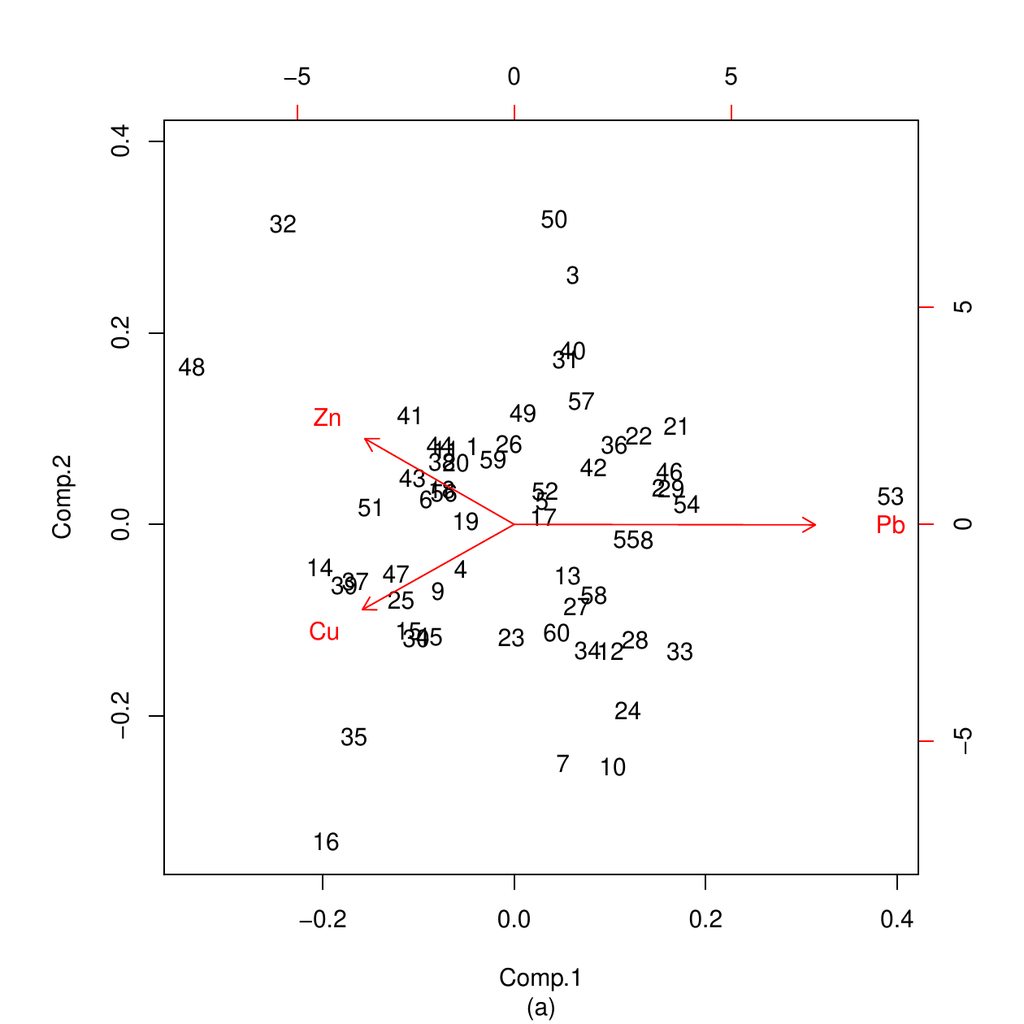

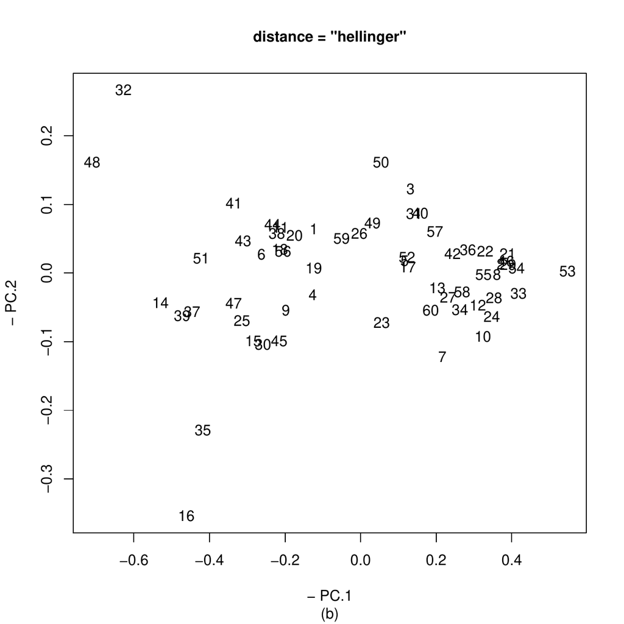

Figure 7: Compositional data. (a) The two first principal components of `princomp.acomp` applied on `sa.lognormals` data. (b) The two first principal coordinates of `mdsdd` on the same data. The signs of the scores are chosen so that the comparison of the two graphs is easier.

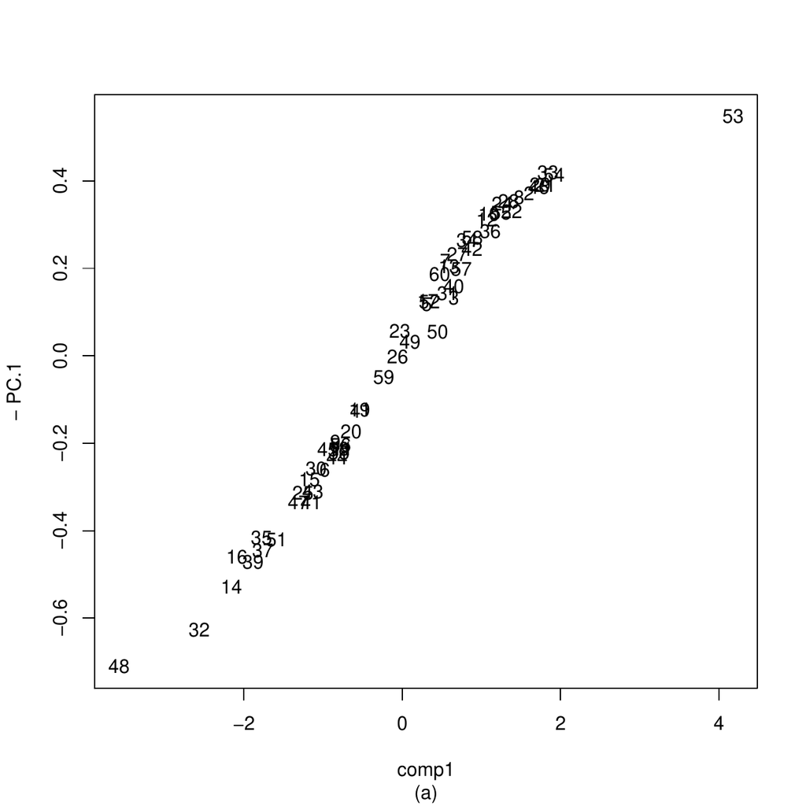

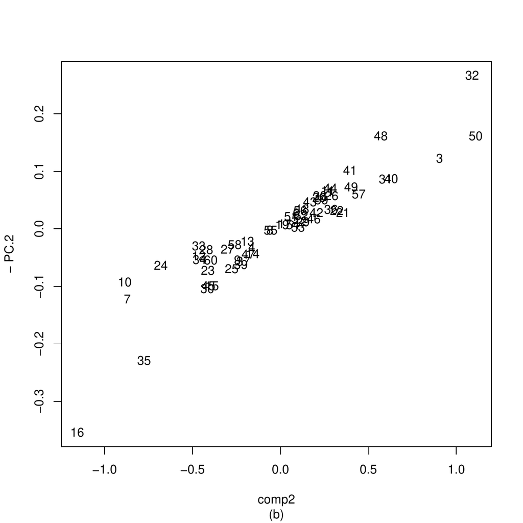

Figure 8: Plots of the scores of the figure a and those of the figure b. The correlation between `comp1` and `-PC.1` is 0.98 and between `comp2` and `-PC.2` is 0.93.

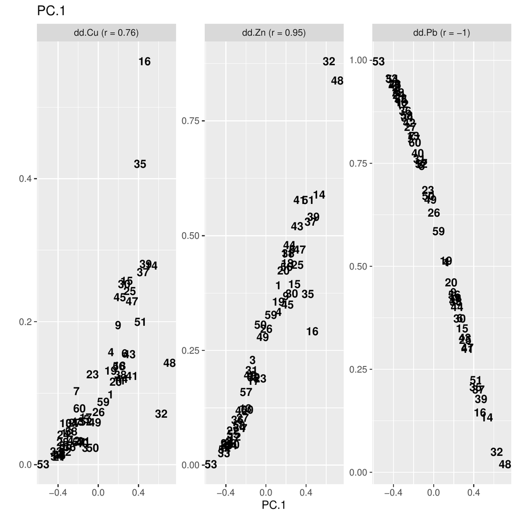

Figure 9: MDS of compositional data considered as discrete densities. Plotting `PC.1` against the relative amounts of `Cu`, `Zn`, and `Pb`.

The discrete densities considered in *dad* are compositional data as they are made up of positive numbers whose sums are one. It is possible to apply to them the techniques developed in the package *compositions* after an adapted data formatting work. The opposite, i.e., applying *dad* techniques to compositional data, is partly true as in the following example illustrating the functions `princomp.acomp` of *compositions* and `mdsdd` of *dad* on the same data.

### 18.1 Data loading

The simulated data `sa.lognormals` of *compositions* are stored in a matrix $60\,\times\,3$ whose columns are the amounts of `Cu`, `Zn`, and `Pb` present in 60 samples. They are loaded as follows.

```r
  > library(compositions)
  > data(SimulatedAmounts)
  > print(sa.lognormals)
```

```r
                Cu          Zn         Pb
   [1,]  8.8043262  35.1671810  45.895025
  ...
  [60,]  3.9854998   6.1301909  40.579417
```

These initial data are transformed so that each row is of sum 1 by means of the `acomp` function.

```r
  > acomp(sa.lognormals) -> x1
  > print(x1)
```

```r
        Cu          Zn          Pb
   [1,] 0.097971136 0.391326782 0.51070208
  ...
  [60,] 0.078617049 0.120922730 0.80046022
  attr(,"class")
  [1] acomp
```

The rows of the object `x1` of class `acomp` (relative amounts of `Cu`, `Zn`, and `Pb` present in 60 samples) are transformed into tables or arrays. These tables or arrays then are organized in a list to be subjected to `mdsdd`. The three levels of the unique categorical variable are denoted `dd.Cu`, `dd.Zn`, and `dd.Pb`.

```r
  > x <- as.data.frame(x1)
  > nomscol <- colnames(x)
  > x2 <- list()
  > for(i in 1:60) {x2[[i]] <- as.table(as.numeric(x[i,]));
  +                                 dimnames(x2[[i]]) <- list("dd" = nomscol)}
  > names(x2) <- rownames(x)
```

### 18.2 Outputs of `princomp` and `mdsdd`

By applying the `princomp.acomp` (or simply `princomp`) function to `x1`, we obtain the visualization of the data in a biplot (Fig. 7a).

The `mdsdd` function (MDS of discrete densities) is applied to `x2` which are the rows of `x1` considered as discrete densities. We choose to present the results for the `distance` argument set to `hellinger`. These results are quite similar to those obtained with other distances as `chisqsym`, `jeffreys`, or `jensen`.

```r
  r2 = mdsdd(x2, distance = "hellinger")
```

It provides the figure 7b.

The two figures are almost equivalent: by plotting the coordinates `comp1` and `comp2` against `PC.1` and `PC.2` of the two previous graphics we get the figure 8.

### 18.3 Interpretation of the scores

For the interpretation of the axes, the two packages provide quite different tools. With *compositions*, the biplot makes it possible to visualize the links between the variables `Cu`, `Zn`, and `Pb` and their links with the principal components. With *dad*, the interpretation is done by crossing the scores and the initial data. The interpretation is based on the strength of the links between the PCs and the probabilities of occurence of each level. In the compositional data example, almost a single axis would suffice to explain the general trend: the first principal coordinate `PC.1` explains 90% of the inertia.

```r
  > interpret(r2, nscore = 1)
```

```r
  Pearson correlations between scores and probability distributions of each variable
  ...
  Spearman correlations between scores and probability distributions of each variable
         PC.1
  dd.Cu  0.90
  dd.Zn  0.96
  dd.Pb -1.00
```

The graphical output is shown in Figure 9. The relative amounts are highly correlated with `PC.1`, showing that a low relative amount of the `dd.Pb` level corresponds to a high relative amount of the levels `dd.Cu` or `dd.Zn`. It is the result suggested by the biplot (Fig. 7a) returned by the function `princomp.acomp` of the package *compositions*.

### 18.4 CRAN packages used

stats, MASS, ade4, FactoMineR, cluster, dad, fda, fda.usc, fdadensity, compositions, Compositional, robCompositions

### 18.5 CRAN Task Views implied by cited packages

ChemPhys, Cluster, CompositionalData, Distributions, Econometrics, Environmetrics, FunctionalData, MissingData, MixedModels, NumericalMathematics, Psychometrics, Robust, Spatial, TeachingStatistics

J. Aitchison. *The statistical analysis of compositional data.* London: Chapman & Hall, 1986. URL http://links.jstor.org/sici?sici=0035-9246\%281982\%2944\%3A2\%3C139\%3ATSAOCD\%3E2.0.CO\%3B2-9.

R. Boumaza. Analyse en composantes principales de distributions gaussiennes multidimensionnelles. *Revue de Statistique Appliquée*, XLVI(2): 5–20, 1998. URL http://www.numdam.org/item?id=RSA_1998__46_2_5_0.

R. Boumaza. Discriminant analysis with independently repeated multivariate measurements: An $L^2$ approach. *Computational Statistics and Data Analysis*, 47(4): 823–843, 2004. URL https://doi.org/10.1016/j.csda.2004.01.001.

R. Boumaza, P. Santagostini, S. Yousfi, G. Hunault, J. Bourbeillon, B. Pumo and S. Demotes-Mainard. *: Three-way / multigroup data analysis through densities.* 2021. URL https://CRAN.R-project.org/package=dad. R Package version 3.4.6.

R. Boumaza, S. Yousfi and S. Demotes-Mainard. Interpreting the principal component analysis of multivariate density functions. *Communications in Statistics - Theory and Methods*, 44(16): 3321–3339, 2015. URL https://doi.org/10.1080/03610926.2013.824103.

T. F. Cox and M. A. A. Cox. *Multidimensional scaling.* Boca Raton: Chapman & Hall/CRC, 2001. URL https://www.bibsonomy.org/bibtex/29a4eb97dc9592c07e19b9c4d8828a91a.

P. Delicado. Dimensionality reduction when data are density functions. *Computational Statistics and Data Analysis*, 55: 401–420, 2011. URL https://doi.org/10.1016/j.csda.2010.05.008.

M. M. Deza and E. Deza. *Encyclopedia of distances.* Heidelberg: Springer-Verlag, 2013. URL https://doi.org/10.1007/978-3-642-00234-2_1.

S. Dray, A.-B. Dufour and D. Chessel. The package – II: Two-table and K-table methods. *R News*, 7(2): 47–52, 2007. URL https://cran.r-project.org/doc/Rnews/.

A. Eslami, E. M. Qannari, S. Bougeard and G. Sanchez. *: Multigroup data analysis.* 2020. URL https://CRAN.R-project.org/package=multigroup. R package version 0.4.5.

A. Eslami, E. M. Qannari, A. Kohler and S. Bougeard. General overview of methods of analysis of multi-group datasets. *Revue des Nouvelles Technologies de l’Information*, 25: 108–123, 2013. URL https://editions-rnti.fr/?inprocid=1001883.

M. Febrero-Bande and M. O. de la Fuente. Statistical computing in functional data analysis: The r package. *Journal of Statistical Software*, 51(4): 1–28, 2012. URL http://www.jstatsoft.org/v51/i04/.

P. Filzmoser, K. Hron and M. Templ. *Applied compositional data analysis. With worked examples in R.* Springer International Publishing. Springer Nature Switzerland AG, Cham, Switzerland, 2018. Springer Series in Statistics.

G. Gan, C. Ma and J. Wu. *Data clustering: Theory, algorithms and applications.* SIAM,Philadelphia, ASA, Alexandria, VA: ASA-SIAM Series on Statistics; Applied Probability, 2007.

C. Godin and Y. Caraglio. A multiscale model of plant topological structures. *Journal of Theoretical Biology*, 191(1): 1–46, 1998. URL https://doi.org/10.1006/jtbi.1997.0561.

INSEE. Population active de 25 à 54 ans ayant un emploi et chômeurs par catégorie socioprofessionnelle et diplôme par commune et département (1968 à 2015): Recensements harmonisés - séries départementales et communales. 2018. URL http://www.insee.fr/fr/statistiques/1893185. Accessed = 2019-06-25.

H. A. L. Kiers. Towards a standardized notation and terminology in multiway analysis. *Journal of Chemometrics*, 14: 105–122, 2000. URL https://doi.org/10.1002/1099-128X(200005/06)14:3<105::AID-CEM582>3.0.CO;2-I.

A. Kneip and K. J. Utikal. Inference for density families using functional principal component analysis. *Journal of the American Statistical Association*, 96: 519–542, 2001. URL https://doi.org/10.1198/016214501753168235.

W. J. Krzanowski. *Principles of multivariate analysis.* New-York: Oxford University Press, 1988.

C. Lavit, Y. Escoufier, R. Sabatier and P. Traissac. The ACT (STATIS method). *Computational Statistics & Data Analysis*, 18: 97–119, 1994. URL https://doi.org/10.1016/0167-9473(94)90134-1.

S. Lê, J. Josse and F. Husson. : An r package for multivariate analysis. *Journal of Statistical Software*, 25(1): 1–18, 2008. URL https://doi.org/10.18637/jss.v025.i01.

M. Maechler, P. Rousseeuw, A. Struyf, M. Hubert and K. Hornik. *: Cluster analysis basics and extensions.* 2019. URL https://CRAN.R-project.org/package=cluster. R package version 2.1.0 — For new features, see the ’Changelog’ file (in the package source).

K. V. Mardia, J. T. Kent and J. M. Bibby. *Multivariate analysis.* London: Academic Press, 1979.

A. Petersen, P. Z. Hadjipantelis and H. G. Mueller. *: Functional data analysis for density functions by transformation to a hilbert space.* 2019. URL https://CRAN.R-project.org/package=fdadensity. R package version 0.1.2.

C. Pradal and T. Cokelaer. *VPlants documentation. Release 0.8.* INRIA, France. Software Environment for Plant Modeling, 2010. URL http://openalea.gforge.inria.fr/doc/vplants/newmtg/doc/_build/html/contents.html.

J. O. Ramsay, S. Graves and G. Hooker. *: Functional data analysis.* 2020. URL https://CRAN.R-project.org/package=fda. R Package version 5.1.4.

J. M. Rudrauf and R. Boumaza. Contribution à l’étude de l’architecture médiévale: Les caractéristiques des pierres à bossage des châteaux forts alsaciens. *Centre de Recherches Archéologiques Médiévales de Saverne*, 5: 5–38, 2001. URL http://www.crams.fr/publications_detail.php?parPUBL=CFA05\#ancDebut.

M. Tsagris and G. Athineou. *: Compositional data analysis.* 2020. URL https://CRAN.R-project.org/package=Compositional. R package version 3.8.

K. G. van den Boogaart, R. Tolosana-Delgado and M. Bren. *: Compositional data analysis.* 2020. URL https://CRAN.R-project.org/package=compositions. R package version 1.40-5.

W. N. Venables and B. D. Ripley. *Modern applied statistics with s.* Fourth New York: Springer-Verlag, 2002. URL http://www.stats.ox.ac.uk/pub/MASS4. ISBN 0-387-95457-0.

M. P. Wand and M. C. Jones. *Kernel smoothing.* London: Chapman; Hall, 1995.

S. Yousfi, R. Boumaza, D. Aissani and S. Adjabi. Optimal bandwith matrices in functional principal component analysis of density functions. *Journal of Statistical Computational and Simulation*, 85(11): 2315–2330, 2015. URL https://doi.org/10.1080/00949655.2014.928293.